# Overview data analysis

L. Bettera & M. Dreier

13 March 2023

# Microbial counts of source material and final cultures

```r
# Uploading the files and creating subsets
fp <- file.path(getwd(), "..", "data", "cultures", "microbes", "viable_counts.xlsx")
df <- read.xlsx(fp, sheet = 1) # import in R the dataset (excel file) as dataframe

# let's transform the first variable in factor (useful for data exploration by groups)
df <- df %>% mutate_at(vars(sample, replicate),
                       as.factor)
# let's remove the repl. 1 because considered outlier from NGS analysis
df <- subset(df, replicate != "1")
df <- df[-2] # let's remove the "replicate" column
```

We analyzed 12 samples:

1. RM = raw milk
2. RM.H = raw milk heat treated (54°C for 54min)
3. eRM = enriched raw milk (spontaneous fermentation at 10°C for 21d)
4. eRM.H = enriched heated raw milk
5. eRM.HS = enriched heated, salted raw milk (5% v/w NaCl)
6. NWC = natural whey culture (thermophilic)
7. eRWC.y = enriched raw milk whey culture, young. Mix NWC-eRM (1:10), incubated at 38°C for 6h
8. eRWC.o = old, incubated at 38°C for 22h
9. eRWC.H.y = mix NWC-eRM.H (1:10), young
10. eRWC.H.o = mix NWC-eRM.H (1:10), old
11. eRWC.HS.y = mix NWC-eRM.HS (1:10), young
12. eRWC.HS.o = mix NWC-eRM.HS (1:10), old

Here is a summary statistic of the results divided for each sample:

```r
dstats <- function(x)sapply(x, mystats)
dfstats <- by(df[2:9],
              list(sample = df$sample), dstats)
dfstats
```

```
## sample: eRM
##       Aerobic.mesophile Streptococci Lactobacilli FH.lactobacilli Enterococci
## n                   3.0          3.0          3.0             3.0         3.0
## mean                9.2          9.1          9.1             3.6         6.8
## stdev               0.0          0.2          0.2             0.6         1.3
## max                 9.2          9.3          9.3             4.0         8.0
## min                 9.2          8.9          8.9             2.9         5.4
##       Yeasts.and.molds Staphylococci Enterobacteriaceae
## n                  3.0           3.0                3.0
## mean               4.6           6.8                6.5
## stdev              0.4           0.5                0.8
## max                5.1           7.3                7.4
## min                4.3           6.3                5.8
## ------------------------------------------------------------
## sample: eRM.H
##       Aerobic.mesophile Streptococci Lactobacilli FH.lactobacilli Enterococci
## n                   3.0          3.0          3.0             3.0         3.0
## mean                7.9          7.7          7.6             3.1         7.0
## stdev               0.4          0.6          1.2             0.7         0.7
## max                 8.3          8.1          8.9             3.8         7.7
## min                 7.5          7.0          6.5             2.6         6.4
##       Yeasts.and.molds Staphylococci Enterobacteriaceae
## n                  3.0           3.0                3.0
## mean               3.8           6.6                6.8
## stdev              1.4           1.0                1.0
## max                5.4           7.7                7.4
## min                2.8           5.8                5.7
## ------------------------------------------------------------
## sample: eRM.HS
##       Aerobic.mesophile Streptococci Lactobacilli FH.lactobacilli Enterococci
## n                   3.0          3.0          3.0             3.0         3.0
## mean                6.6          6.1          4.5             0.4         4.7
## stdev               0.4          1.2          0.8             0.6         0.7
## max                 6.8          7.0          5.4             1.1         5.4
## min                 6.2          4.8          4.1             0.0         4.3
##       Yeasts.and.molds Staphylococci Enterobacteriaceae
## n                  3.0           3.0                3.0
## mean               1.3           6.0                3.7
## stdev              1.5           1.1                0.4
## max                2.9           6.7                4.2
```

[output cut: 112 more lines]

```
## min                0.8           4.1                1.3
## ------------------------------------------------------------
## sample: RM.H
##       Aerobic.mesophile Streptococci Lactobacilli FH.lactobacilli Enterococci
## n                   3.0          3.0          3.0               3         3.0
## mean                2.1          1.4          0.8               0         0.7
## stdev               0.2          0.2          0.3               0         0.3
## max                 2.4          1.7          1.2               0         1.0
## min                 1.9          1.2          0.5               0         0.4
##       Yeasts.and.molds Staphylococci Enterobacteriaceae
## n                    3             3                3.0
## mean                 0             1                0.3
## stdev                0             0                0.3
## max                  0             1                0.5
## min                  0             1                0.0
```

## Data analysis: RM and eRM

### Boxplot

This boxplot shows the spontaneous fermentation effect of RM on the concentration of different microbial groups.

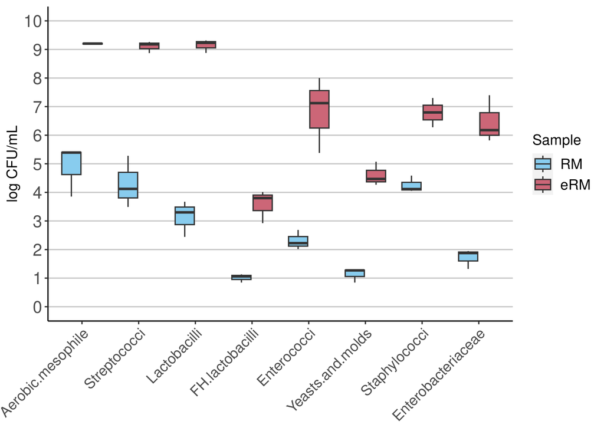

```r
# for boxplots, the dataset in melted form is preferred
df2 <- melt(df, id = "sample", value.name = "CFU_mL")
```

## Statistics

Statistical analysis was performed in order to define whether the evaluated differences were significant. If the variances of the two groups resulted homogeneous to the Fisher’s test, a Two Sample t-test was applied; alternatively a Welch t-test was used.

```r
# variance homogeneity (for interpretation http://www.sthda.com/english/wiki/f-test-compare-two-variances-in-r)
# If p-value>0.05 variances are homogeneous

sample_names <- c("RM", "eRM")

subdf2 <- filter(df2, sample %in% sample_names)
m_vars = unique(subdf2$variable)

for (x in m_vars) {
  test_two_grps(x, subdf2, sample_names)
}
```

```
## Aerobic.mesophile
```

```
##
##  F test to compare two variances
##
## data:  Aerobic.mesophile RM eRM
## F = 1259.2, num df = 2, denom df = 2, p-value = 0.001587
## alternative hypothesis: true ratio of variances is not equal to 1
## 95 percent confidence interval:
##     32.28679 49108.21118
## sample estimates:
## ratio of variances
##           1259.185
```

```
##
##  Welch Two Sample t-test
##
## data:  Aerobic.mesophile RM eRM
## t = -8.3527, df = 2.0032, p-value = 0.01397
## alternative hypothesis: true difference in means is not equal to 0
## 95 percent confidence interval:
##  -6.533301 -2.095297
## sample estimates:
## mean of x mean of y
##  4.886033  9.200332
```

```
## Streptococci
```

```
##
##  F test to compare two variances
##
## data:  Streptococci RM eRM
## F = 19.668, num df = 2, denom df = 2, p-value = 0.09677
## alternative hypothesis: true ratio of variances is not equal to 1
## 95 percent confidence interval:
##    0.5042989 767.0386708
## sample estimates:
## ratio of variances
##           19.66766
```

```
##
##  Two Sample t-test
##
## data:  Streptococci RM eRM
## t = -8.9479, df = 4, p-value = 0.0008629
## alternative hypothesis: true difference in means is not equal to 0
## 95 percent confidence interval:
##  -6.298119 -3.315205
## sample estimates:
## mean of x mean of y
##  4.297291  9.103953
```

```
## Lactobacilli
```

```
##
##  F test to compare two variances
##
## data:  Lactobacilli RM eRM
## F = 7.3998, num df = 2, denom df = 2, p-value = 0.2381
## alternative hypothesis: true ratio of variances is not equal to 1
## 95 percent confidence interval:
##    0.189739 288.593026
## sample estimates:
## ratio of variances
##           7.399821
```

```
##
##  Two Sample t-test
##
## data:  Lactobacilli RM eRM
## t = -15.478, df = 4, p-value = 0.0001017
## alternative hypothesis: true difference in means is not equal to 0
## 95 percent confidence interval:
##  -7.079545 -4.926023
## sample estimates:
## mean of x mean of y
##  3.138678  9.141463
```

```
## FH.lactobacilli
```

```
##
##  F test to compare two variances
##
## data:  FH.lactobacilli RM eRM
## F = 0.066598, num df = 2, denom df = 2, p-value = 0.1249
## alternative hypothesis: true ratio of variances is not equal to 1
## 95 percent confidence interval:
##  0.001707631 2.597307275
## sample estimates:
## ratio of variances
##         0.06659762
```

```
##
##  Two Sample t-test
##
## data:  FH.lactobacilli RM eRM
## t = -7.4693, df = 4, p-value = 0.001717
## alternative hypothesis: true difference in means is not equal to 0
## 95 percent confidence interval:
##  -3.520483 -1.612494
## sample estimates:
## mean of x mean of y
##  1.012043  3.578532
```

```
## Enterococci
```

```
##
##  F test to compare two variances
##
## data:  Enterococci RM eRM
## F = 0.066201, num df = 2, denom df = 2, p-value = 0.1242
## alternative hypothesis: true ratio of variances is not equal to 1
## 95 percent confidence interval:
##  0.001697462 2.581839190
## sample estimates:
## ratio of variances
##           0.066201
```

```
##
##  Two Sample t-test
##
## data:  Enterococci RM eRM
## t = -5.6935, df = 4, p-value = 0.004701
## alternative hypothesis: true difference in means is not equal to 0
## 95 percent confidence interval:
##  -6.732632 -2.318703
## sample estimates:
## mean of x mean of y
##  2.308226  6.833894
```

```
## Yeasts.and.molds
```

```
##
##  F test to compare two variances
##
## data:  Yeasts.and.molds RM eRM
## F = 0.36077, num df = 2, denom df = 2, p-value = 0.5302
## alternative hypothesis: true ratio of variances is not equal to 1
## 95 percent confidence interval:
##   0.00925047 14.06996547
## sample estimates:
## ratio of variances
##          0.3607683
```

```
##
##  Two Sample t-test
##
## data:  Yeasts.and.molds RM eRM
## t = -12.302, df = 4, p-value = 0.0002508
## alternative hypothesis: true difference in means is not equal to 0
## 95 percent confidence interval:
##  -4.250444 -2.685144
## sample estimates:
## mean of x mean of y
##  1.135165  4.602959
```

```
## Staphylococci
```

```
##
##  F test to compare two variances
##
## data:  Staphylococci RM eRM
## F = 0.32397, num df = 2, denom df = 2, p-value = 0.4894
## alternative hypothesis: true ratio of variances is not equal to 1
## 95 percent confidence interval:
##   0.008306854 12.634724784
## sample estimates:
## ratio of variances
##          0.3239673
```

```
##
##  Two Sample t-test
##
## data:  Staphylococci RM eRM
## t = -7.4707, df = 4, p-value = 0.001716
## alternative hypothesis: true difference in means is not equal to 0
## 95 percent confidence interval:
##  -3.483523 -1.595822
## sample estimates:
## mean of x mean of y
##  4.251834  6.791506
```

```
## Enterobacteriaceae
```

```
##
##  F test to compare two variances
##
## data:  Enterobacteriaceae RM eRM
## F = 0.17114, num df = 2, denom df = 2, p-value = 0.2923
## alternative hypothesis: true ratio of variances is not equal to 1
## 95 percent confidence interval:
##  0.004388145 6.674369066
## sample estimates:
## ratio of variances
##          0.1711377
```

```
##
##  Two Sample t-test
##
## data:  Enterobacteriaceae RM eRM
## t = -9.1823, df = 4, p-value = 0.0007812
## alternative hypothesis: true difference in means is not equal to 0
## 95 percent confidence interval:
##  -6.185142 -3.313153
## sample estimates:
## mean of x mean of y
##  1.715616  6.464764
```

## Data analysis: RM.H, eRM.H and eRM.HS

### Statistics

Statistical analysis was performed in order to define whether the evaluated differences were significant. If the variances of the two groups resulted homogeneous to the Fisher’s test, a Two Sample t-test was applied; alternatively a Welch t-test was used.

```r
sample_names <- c("RM.H", "eRM.H")

subdf3 <- filter(df2, sample %in% sample_names)
m_vars = unique(subdf3$variable)

for (x in m_vars) {
  test_two_grps(x, subdf3, sample_names)
}
```

```
## Aerobic.mesophile
```

```
##
##  F test to compare two variances
##
## data:  Aerobic.mesophile RM.H eRM.H
## F = 0.31509, num df = 2, denom df = 2, p-value = 0.4792
## alternative hypothesis: true ratio of variances is not equal to 1
## 95 percent confidence interval:
##   0.008079148 12.288383389
## sample estimates:
## ratio of variances
##          0.3150868
```

```
##
##  Two Sample t-test
##
## data:  Aerobic.mesophile RM.H eRM.H
## t = -20.94, df = 4, p-value = 3.074e-05
## alternative hypothesis: true difference in means is not equal to 0
## 95 percent confidence interval:
##  -6.49363 -4.97324
## sample estimates:
## mean of x mean of y
##  2.147064  7.880499
```

```
## Streptococci
```

```
##
##  F test to compare two variances
##
## data:  Streptococci RM.H eRM.H
## F = 0.14824, num df = 2, denom df = 2, p-value = 0.2582
## alternative hypothesis: true ratio of variances is not equal to 1
## 95 percent confidence interval:
##  0.00380113 5.78151875
## sample estimates:
## ratio of variances
##          0.1482441
```

```
##
##  Two Sample t-test
##
## data:  Streptococci RM.H eRM.H
## t = -16.409, df = 4, p-value = 8.075e-05
## alternative hypothesis: true difference in means is not equal to 0
## 95 percent confidence interval:
##  -7.294157 -5.183017
## sample estimates:
## mean of x mean of y
##  1.441008  7.679595
```

```
## Lactobacilli
```

```
##
##  F test to compare two variances
##
## data:  Lactobacilli RM.H eRM.H
## F = 0.074013, num df = 2, denom df = 2, p-value = 0.1378
## alternative hypothesis: true ratio of variances is not equal to 1
## 95 percent confidence interval:
##  0.001897766 2.886501454
## sample estimates:
## ratio of variances
##         0.07401286
```

```
##
##  Two Sample t-test
##
## data:  Lactobacilli RM.H eRM.H
## t = -9.3259, df = 4, p-value = 0.0007359
## alternative hypothesis: true difference in means is not equal to 0
## 95 percent confidence interval:
##  -8.768099 -4.745050
## sample estimates:
## mean of x mean of y
## 0.8063764 7.5629511
```

```
## FH.lactobacilli
```

```
##
##  F test to compare two variances
##
## data:  FH.lactobacilli RM.H eRM.H
## F = 0, num df = 2, denom df = 2, p-value < 2.2e-16
## alternative hypothesis: true ratio of variances is not equal to 1
## 95 percent confidence interval:
##  0 0
## sample estimates:
## ratio of variances
##                  0
```

```
##
##  Welch Two Sample t-test
##
## data:  FH.lactobacilli RM.H eRM.H
## t = -7.5974, df = 2, p-value = 0.01689
## alternative hypothesis: true difference in means is not equal to 0
## 95 percent confidence interval:
##  -4.777612 -1.322770
## sample estimates:
## mean of x mean of y
##  0.000000  3.050191
```

```
## Enterococci
```

```
##
##  F test to compare two variances
##
## data:  Enterococci RM.H eRM.H
## F = 0.2267, num df = 2, denom df = 2, p-value = 0.3696
## alternative hypothesis: true ratio of variances is not equal to 1
## 95 percent confidence interval:
##  0.005812843 8.841334385
## sample estimates:
## ratio of variances
##          0.2267009
```

```
##
##  Two Sample t-test
##
## data:  Enterococci RM.H eRM.H
## t = -14.306, df = 4, p-value = 0.0001387
## alternative hypothesis: true difference in means is not equal to 0
## 95 percent confidence interval:
##  -7.421818 -5.009321
## sample estimates:
## mean of x mean of y
## 0.7391613 6.9547307
```

```
## Yeasts.and.molds
```

```
##
##  F test to compare two variances
##
## data:  Yeasts.and.molds RM.H eRM.H
## F = 0, num df = 2, denom df = 2, p-value < 2.2e-16
## alternative hypothesis: true ratio of variances is not equal to 1
## 95 percent confidence interval:
##  0 0
## sample estimates:
## ratio of variances
##                  0
```

```
##
##  Welch Two Sample t-test
##
## data:  Yeasts.and.molds RM.H eRM.H
## t = -4.6892, df = 2, p-value = 0.04259
## alternative hypothesis: true difference in means is not equal to 0
## 95 percent confidence interval:
##  -7.2665373 -0.3123594
## sample estimates:
## mean of x mean of y
##  0.000000  3.789448
```

```
## Staphylococci
```

```
##
##  F test to compare two variances
##
## data:  Staphylococci RM.H eRM.H
## F = 0.0010706, num df = 2, denom df = 2, p-value = 0.002139
## alternative hypothesis: true ratio of variances is not equal to 1
## 95 percent confidence interval:
##  2.745184e-05 4.175425e-02
## sample estimates:
## ratio of variances
##        0.001070622
```

```
##
##  Welch Two Sample t-test
##
## data:  Staphylococci RM.H eRM.H
## t = -9.8263, df = 2.0043, p-value = 0.01013
## alternative hypothesis: true difference in means is not equal to 0
## 95 percent confidence interval:
##  -8.054171 -3.155723
## sample estimates:
## mean of x mean of y
##  1.006372  6.611319
```

```
## Enterobacteriaceae
```

```
##
##  F test to compare two variances
##
## data:  Enterobacteriaceae RM.H eRM.H
## F = 0.078156, num df = 2, denom df = 2, p-value = 0.145
## alternative hypothesis: true ratio of variances is not equal to 1
## 95 percent confidence interval:
##  0.002003998 3.048080460
## sample estimates:
## ratio of variances
##         0.07815591
```

```
##
##  Two Sample t-test
##
## data:  Enterobacteriaceae RM.H eRM.H
## t = -11.127, df = 4, p-value = 0.0003712
## alternative hypothesis: true difference in means is not equal to 0
## 95 percent confidence interval:
##  -8.125806 -4.880450
## sample estimates:
## mean of x mean of y
## 0.2816993 6.7848271
```

```r
sample_names <- c("RM.H", "eRM.HS")

subdf4 <- filter(df2, sample %in% sample_names)
m_vars = unique(subdf4$variable)

for (x in m_vars) {
  test_two_grps(x, subdf4, sample_names)
}
```

```
## Aerobic.mesophile
```

```
##
##  F test to compare two variances
##
## data:  Aerobic.mesophile RM.H eRM.HS
## F = 0.38303, num df = 2, denom df = 2, p-value = 0.5539
## alternative hypothesis: true ratio of variances is not equal to 1
## 95 percent confidence interval:
##   0.009821308 14.938209596
## sample estimates:
## ratio of variances
##           0.383031
```

```
##
##  Two Sample t-test
##
## data:  Aerobic.mesophile RM.H eRM.HS
## t = -17.51, df = 4, p-value = 6.246e-05
## alternative hypothesis: true difference in means is not equal to 0
## 95 percent confidence interval:
##  -5.166273 -3.752135
## sample estimates:
## mean of x mean of y
##  2.147064  6.606268
```

```
## Streptococci
```

```
##
##  F test to compare two variances
##
## data:  Streptococci RM.H eRM.HS
## F = 0.039259, num df = 2, denom df = 2, p-value = 0.07555
## alternative hypothesis: true ratio of variances is not equal to 1
## 95 percent confidence interval:
##  0.001006646 1.531108560
## sample estimates:
## ratio of variances
##         0.03925919
```

```
##
##  Two Sample t-test
##
## data:  Streptococci RM.H eRM.HS
## t = -6.6938, df = 4, p-value = 0.002591
## alternative hypothesis: true difference in means is not equal to 0
## 95 percent confidence interval:
##  -6.656113 -2.753282
## sample estimates:
## mean of x mean of y
##  1.441008  6.145705
```

```
## Lactobacilli
```

```
##
##  F test to compare two variances
##
## data:  Lactobacilli RM.H eRM.HS
## F = 0.18764, num df = 2, denom df = 2, p-value = 0.316
## alternative hypothesis: true ratio of variances is not equal to 1
## 95 percent confidence interval:
##  0.004811186 7.317814009
## sample estimates:
## ratio of variances
##          0.1876363
```

```
##
##  Two Sample t-test
##
## data:  Lactobacilli RM.H eRM.HS
## t = -7.8196, df = 4, p-value = 0.001444
## alternative hypothesis: true difference in means is not equal to 0
## 95 percent confidence interval:
##  -5.070072 -2.413097
## sample estimates:
## mean of x mean of y
## 0.8063764 4.5479608
```

```
## FH.lactobacilli
```

```
##
##  F test to compare two variances
##
## data:  FH.lactobacilli RM.H eRM.HS
## F = 0, num df = 2, denom df = 2, p-value < 2.2e-16
## alternative hypothesis: true ratio of variances is not equal to 1
## 95 percent confidence interval:
##  0 0
## sample estimates:
## ratio of variances
##                  0
```

```
##
##  Welch Two Sample t-test
##
## data:  FH.lactobacilli RM.H eRM.HS
## t = -1, df = 2, p-value = 0.4226
## alternative hypothesis: true difference in means is not equal to 0
## 95 percent confidence interval:
##  -1.874837  1.167706
## sample estimates:
## mean of x mean of y
## 0.0000000 0.3535659
```

```
## Enterococci
```

```
##
##  F test to compare two variances
##
## data:  Enterococci RM.H eRM.HS
## F = 0.24012, num df = 2, denom df = 2, p-value = 0.3873
## alternative hypothesis: true ratio of variances is not equal to 1
## 95 percent confidence interval:
##  0.006156912 9.364662884
## sample estimates:
## ratio of variances
##          0.2401196
```

```
##
##  Two Sample t-test
##
## data:  Enterococci RM.H eRM.HS
## t = -9.2414, df = 4, p-value = 0.0007622
## alternative hypothesis: true difference in means is not equal to 0
## 95 percent confidence interval:
##  -5.100919 -2.744015
## sample estimates:
## mean of x mean of y
## 0.7391613 4.6616279
```

```
## Yeasts.and.molds
```

```
##
##  F test to compare two variances
##
## data:  Yeasts.and.molds RM.H eRM.HS
## F = 0, num df = 2, denom df = 2, p-value < 2.2e-16
## alternative hypothesis: true ratio of variances is not equal to 1
## 95 percent confidence interval:
##  0 0
## sample estimates:
## ratio of variances
##                  0
```

```
##
##  Welch Two Sample t-test
##
## data:  Yeasts.and.molds RM.H eRM.HS
## t = -1.5697, df = 2, p-value = 0.257
## alternative hypothesis: true difference in means is not equal to 0
## 95 percent confidence interval:
##  -5.027149  2.339544
## sample estimates:
## mean of x mean of y
##  0.000000  1.343803
```

```
## Staphylococci
```

```
##
##  F test to compare two variances
##
## data:  Staphylococci RM.H eRM.HS
## F = 0.00079951, num df = 2, denom df = 2, p-value = 0.001598
## alternative hypothesis: true ratio of variances is not equal to 1
## 95 percent confidence interval:
##  2.050016e-05 3.118074e-02
## sample estimates:
## ratio of variances
##       0.0007995061
```

```
##
##  Welch Two Sample t-test
##
## data:  Staphylococci RM.H eRM.HS
## t = -7.6195, df = 2.0032, p-value = 0.01672
## alternative hypothesis: true difference in means is not equal to 0
## 95 percent confidence interval:
##  -7.864048 -2.193415
## sample estimates:
## mean of x mean of y
##  1.006372  6.035103
```

```
## Enterobacteriaceae
```

```
##
##  F test to compare two variances
##
## data:  Enterobacteriaceae RM.H eRM.HS
## F = 0.4085, num df = 2, denom df = 2, p-value = 0.58
## alternative hypothesis: true ratio of variances is not equal to 1
## 95 percent confidence interval:
##   0.01047432 15.93144659
## sample estimates:
## ratio of variances
##          0.4084986
```

```
##
##  Two Sample t-test
##
## data:  Enterobacteriaceae RM.H eRM.HS
## t = -11.698, df = 4, p-value = 0.0003054
## alternative hypothesis: true difference in means is not equal to 0
## 95 percent confidence interval:
##  -4.229203 -2.606700
## sample estimates:
## mean of x mean of y
## 0.2816993 3.6996508
```

### Boxplot

Here is shown the microbial enrichment of RM.H, also with addition of salt.

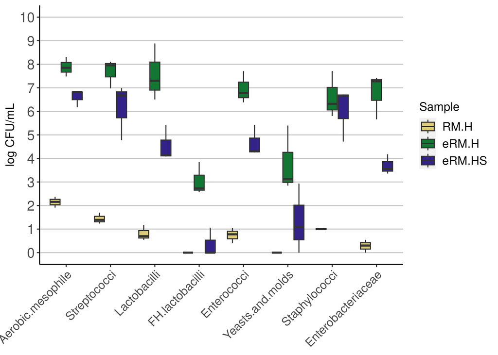

### Statistics

Since here there are more then 2 groups, a one-way ANOVA model was needed for the statistical analysis. The variance homogeneity was previously checked using the Bartlett’s test. In case the assumptions of one-way ANOVA test are not met, a Kruskal-Wallis test is applied. A Multiple Mean Comparison test was eventually performed afterwards.

```r
subdf5 <- filter(df2, sample %in% c("RM.H", "eRM.H", "eRM.HS"))
m_vars = unique(subdf5$variable)

for (x in m_vars) {
  test_more_grps(x, subdf5)
}
```

```
## Aerobic.mesophile
```

```
##
##  Bartlett test of homogeneity of variances
##
## data:  Aerobic.mesophile
## Bartlett's K-squared = 0.54578, df = 2, p-value = 0.7612
```

```
##             Df Sum Sq Mean Sq F value   Pr(>F)
## sample       2  54.38  27.190   223.1 2.34e-06 ***
## Residuals    6   0.73   0.122
## ---
## Signif. codes:  0 '***' 0.001 '**' 0.01 '*' 0.05 '.' 0.1 ' ' 1
```

```
##   Tukey multiple comparisons of means
##     95% family-wise confidence level
##
## Fit: aov(formula = CFU_mL ~ sample)
##
## $sample
##                   diff       lwr        upr     p adj
## eRM.HS-eRM.H -1.274231 -2.148773 -0.3996888 0.0100609
## RM.H-eRM.H   -5.733435 -6.607977 -4.8588929 0.0000023
## RM.H-eRM.HS  -4.459204 -5.333746 -3.5846623 0.0000102
```

```
## Streptococci
```

```
##
##  Bartlett test of homogeneity of variances
##
## data:  Streptococci
## Bartlett's K-squared = 3.3822, df = 2, p-value = 0.1843
```

```
##             Df Sum Sq Mean Sq F value  Pr(>F)
## sample       2  63.41   31.70   51.15 0.00017 ***
## Residuals    6   3.72    0.62
## ---
## Signif. codes:  0 '***' 0.001 '**' 0.01 '*' 0.05 '.' 0.1 ' ' 1
```

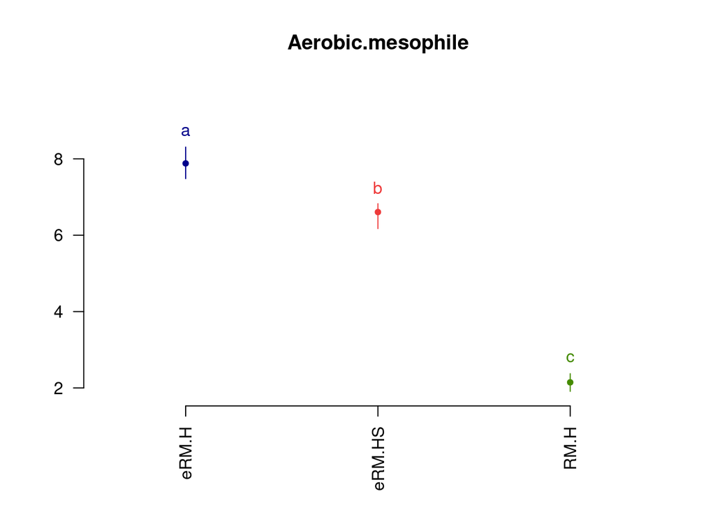

```
##   Tukey multiple comparisons of means
##     95% family-wise confidence level
##
## Fit: aov(formula = CFU_mL ~ sample)
##
## $sample
##                   diff       lwr        upr     p adj
## eRM.HS-eRM.H -1.533890 -3.506316  0.4385357 0.1180403
## RM.H-eRM.H   -6.238587 -8.211013 -4.2661615 0.0001692
## RM.H-eRM.HS  -4.704697 -6.677123 -2.7322715 0.0008120
```

```
## Lactobacilli
```

```
##
##  Bartlett test of homogeneity of variances
##
## data:  Lactobacilli
## Bartlett's K-squared = 2.2755, df = 2, p-value = 0.3205
```

```
##             Df Sum Sq Mean Sq F value   Pr(>F)
## sample       2  68.74   34.37   47.89 0.000205 ***
## Residuals    6   4.31    0.72
## ---
## Signif. codes:  0 '***' 0.001 '**' 0.01 '*' 0.05 '.' 0.1 ' ' 1
```

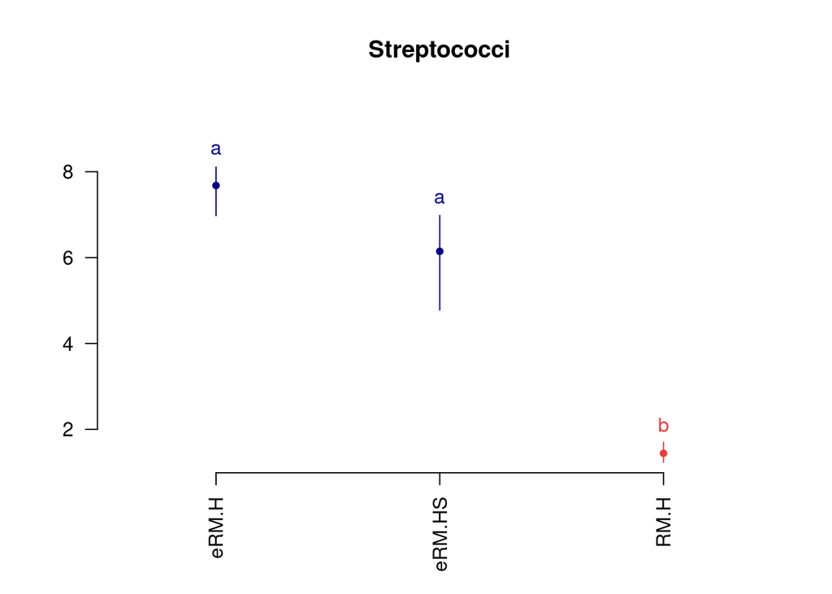

```
##   Tukey multiple comparisons of means
##     95% family-wise confidence level
##
## Fit: aov(formula = CFU_mL ~ sample)
##
## $sample
##                   diff       lwr        upr     p adj
## eRM.HS-eRM.H -3.014990 -5.137313 -0.8926677 0.0113229
## RM.H-eRM.H   -6.756575 -8.878897 -4.6342520 0.0001630
## RM.H-eRM.HS  -3.741584 -5.863907 -1.6192617 0.0039732
```

```
## FH.lactobacilli
```

```
##
##  Bartlett test of homogeneity of variances
##
## data:  FH.lactobacilli
## Bartlett's K-squared = Inf, df = 2, p-value < 2.2e-16
```

```
##
##  Kruskal-Wallis rank sum test
##
## data:  FH.lactobacilli
## Kruskal-Wallis chi-squared = 6.72, df = 2, p-value = 0.03474
```

```
##   Kruskal-Wallis rank sum test
##
##  data: x and g
##  Kruskal-Wallis chi-squared = 6.72, df = 2, p-value = 0.03
##
##
##                               Comparison of x by g
##                                   (Bonferroni)
##  Col Mean-|
##  Row Mean |      eRM.H     eRM.HS
##  ---------+----------------------
##    eRM.HS |   1.959591
##           |     0.1501
##      RM.H |   2.449489   0.489897
##           |    0.0429*     1.0000
##
##  alpha = 0.05
##  Reject Ho if p <= alpha
```

```
## Enterococci
```

```
##
##  Bartlett test of homogeneity of variances
##
## data:  Enterococci
## Bartlett's K-squared = 0.93453, df = 2, p-value = 0.6267
```

```
##             Df Sum Sq Mean Sq F value  Pr(>F)
## sample       2  59.28  29.639   88.73 3.5e-05 ***
## Residuals    6   2.00   0.334
## ---
## Signif. codes:  0 '***' 0.001 '**' 0.01 '*' 0.05 '.' 0.1 ' ' 1
```

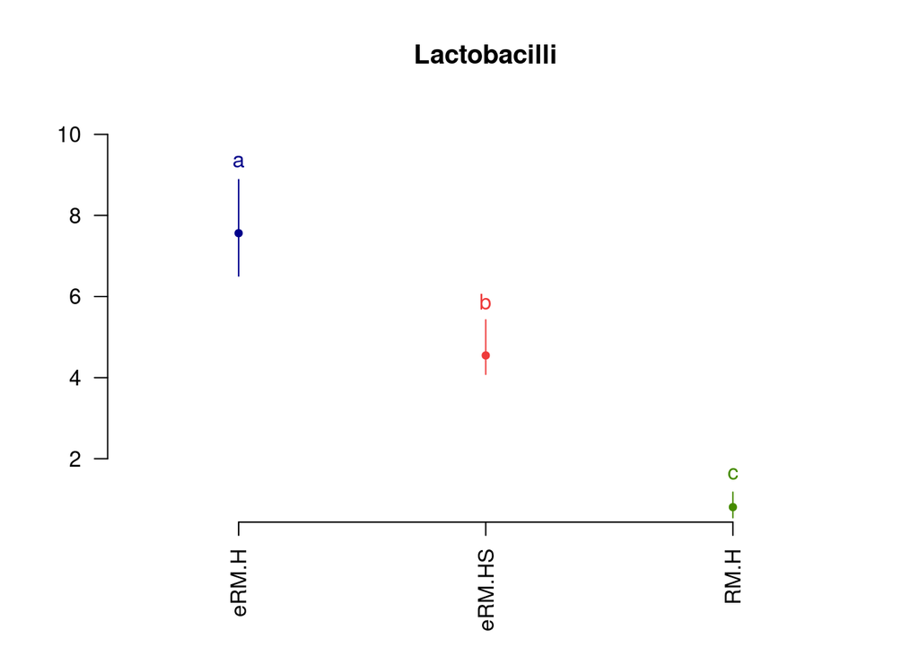

```
##   Tukey multiple comparisons of means
##     95% family-wise confidence level
##
## Fit: aov(formula = CFU_mL ~ sample)
##
## $sample
##                   diff       lwr        upr     p adj
## eRM.HS-eRM.H -2.293103 -3.741002 -0.8452031 0.0067553
## RM.H-eRM.H   -6.215569 -7.663469 -4.7676698 0.0000291
## RM.H-eRM.HS  -3.922467 -5.370366 -2.4745670 0.0004034
```

```
## Yeasts.and.molds
```

```
##
##  Bartlett test of homogeneity of variances
##
## data:  Yeasts.and.molds
## Bartlett's K-squared = Inf, df = 2, p-value < 2.2e-16
```

```
##
##  Kruskal-Wallis rank sum test
##
## data:  Yeasts.and.molds
## Kruskal-Wallis chi-squared = 5.8424, df = 2, p-value = 0.05387
```

```
## Staphylococci
```

```
##
##  Bartlett test of homogeneity of variances
##
## data:  Staphylococci
## Bartlett's K-squared = 9.4948, df = 2, p-value = 0.008674
```

```
##
##  Kruskal-Wallis rank sum test
##
## data:  Staphylococci
## Kruskal-Wallis chi-squared = 5.4222, df = 2, p-value = 0.06646
```

```
## Enterobacteriaceae
```

```
##
##  Bartlett test of homogeneity of variances
##
## data:  Enterobacteriaceae
## Bartlett's K-squared = 2.6555, df = 2, p-value = 0.2651
```

```
##             Df Sum Sq Mean Sq F value   Pr(>F)
## sample       2  63.49   31.75   78.93 4.91e-05 ***
## Residuals    6   2.41    0.40
## ---
## Signif. codes:  0 '***' 0.001 '**' 0.01 '*' 0.05 '.' 0.1 ' ' 1
```

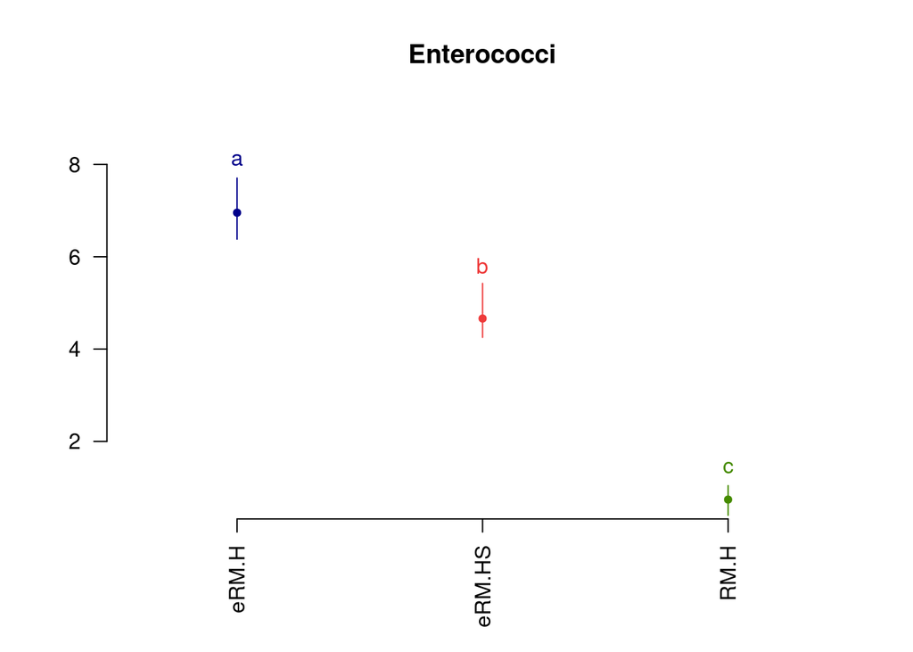

```
##   Tukey multiple comparisons of means
##     95% family-wise confidence level
##
## Fit: aov(formula = CFU_mL ~ sample)
##
## $sample
##                   diff       lwr       upr     p adj
## eRM.HS-eRM.H -3.085176 -4.673958 -1.496395 0.0024235
## RM.H-eRM.H   -6.503128 -8.091909 -4.914346 0.0000384
## RM.H-eRM.HS  -3.417951 -5.006733 -1.829170 0.0014148
```

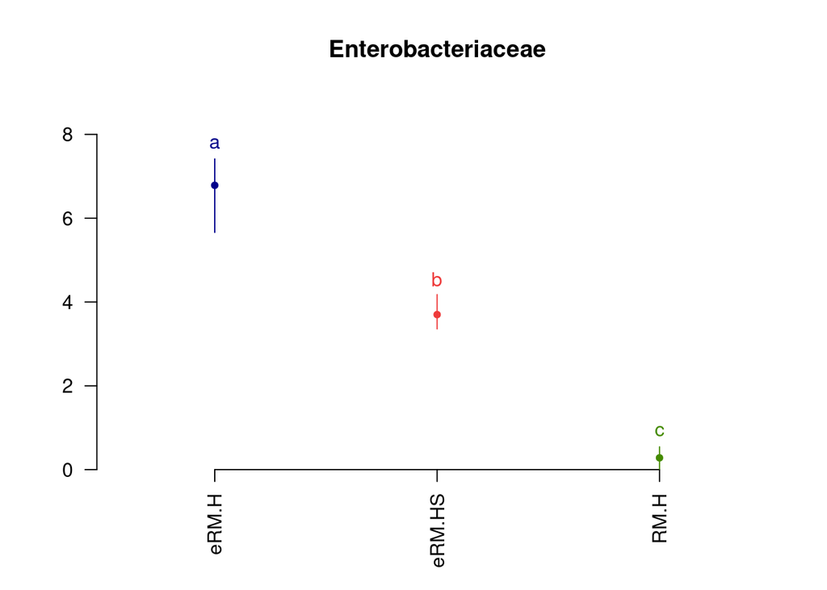

## Data analysis: NWC and final cultures

### Boxplot

This boxplot shows the microbial composition of the final cultures, obtained by incubating the mixture of NWC and the enriched milks.

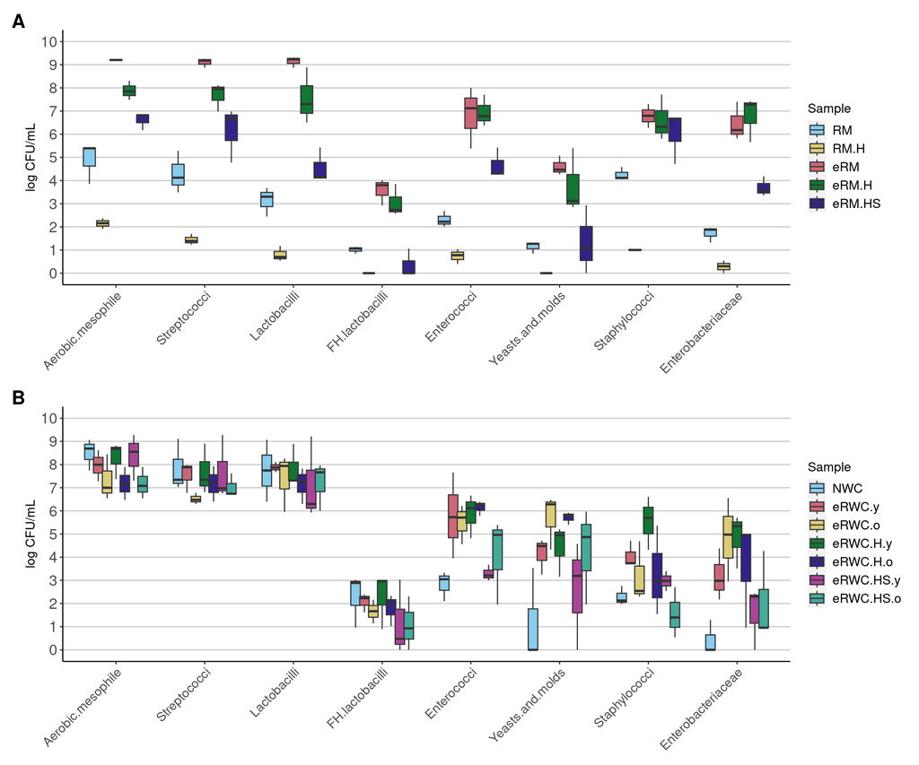

### Testing hypotheses

Since here there are more then 2 groups, a one-way ANOVA model was needed for the statistical analysis. The variance homogeneity was previously checked using the Bartlett’s test. In case the assumptions of one-way ANOVA test are not met, a Kruskal-Wallis test is applied. A Multiple Mean Comparison test was eventually performed afterwards.

```r
selected_samples <- c("NWC", "eRWC.y", "eRWC.o", "eRWC.H.y", "eRWC.H.o", "eRWC.HS.y", "eRWC.HS.o")

subdf6 <- filter(df2, sample %in% selected_samples)
m_vars = unique(subdf6$variable)

for (x in m_vars) {
  test_more_grps(x, subdf6)
}
```

```
## Aerobic.mesophile
```

```
##
##  Bartlett test of homogeneity of variances
##
## data:  Aerobic.mesophile
## Bartlett's K-squared = 0.66898, df = 6, p-value = 0.9951
```

```
##             Df Sum Sq Mean Sq F value Pr(>F)
## sample       6  6.232  1.0386   1.615  0.215
## Residuals   14  9.005  0.6432
```

```
## Streptococci
```

```
##
##  Bartlett test of homogeneity of variances
##
## data:  Streptococci
## Bartlett's K-squared = 5.1667, df = 6, p-value = 0.5226
```

```
##             Df Sum Sq Mean Sq F value Pr(>F)
## sample       6   3.93  0.6550   0.797  0.588
## Residuals   14  11.50  0.8217
```

```
## Lactobacilli
```

```
##
##  Bartlett test of homogeneity of variances
##
## data:  Lactobacilli
## Bartlett's K-squared = 5.5485, df = 6, p-value = 0.4756
```

```
##             Df Sum Sq Mean Sq F value Pr(>F)
## sample       6  1.978  0.3296   0.251  0.951
## Residuals   14 18.379  1.3128
```

```
## FH.lactobacilli
```

```
##
##  Bartlett test of homogeneity of variances
##
## data:  FH.lactobacilli
## Bartlett's K-squared = 4.4453, df = 6, p-value = 0.6166
```

```
##             Df Sum Sq Mean Sq F value Pr(>F)
## sample       6  4.457  0.7429   0.677  0.671
## Residuals   14 15.372  1.0980
```

```
## Enterococci
```

```
##
##  Bartlett test of homogeneity of variances
##
## data:  Enterococci
## Bartlett's K-squared = 8.6924, df = 6, p-value = 0.1916
```

```
##             Df Sum Sq Mean Sq F value Pr(>F)
## sample       6  33.15   5.525    4.21 0.0125 *
## Residuals   14  18.37   1.312
## ---
## Signif. codes:  0 '***' 0.001 '**' 0.01 '*' 0.05 '.' 0.1 ' ' 1
```

```
##   Tukey multiple comparisons of means
##     95% family-wise confidence level
##
## Fit: aov(formula = CFU_mL ~ sample)
##
## $sample
##                            diff        lwr        upr     p adj
## eRWC.H.y-eRWC.H.o   -0.28049937 -3.4745060  2.9135072 0.9999160
## eRWC.HS.o-eRWC.H.o  -2.04331342 -5.2373200  1.1506932 0.3609038
## eRWC.HS.y-eRWC.H.o  -2.85237603 -6.0463826  0.3416306 0.0946776
## eRWC.o-eRWC.H.o     -0.65004973 -3.8440564  2.5439569 0.9907539
## eRWC.y-eRWC.H.o     -0.36719217 -3.5611988  2.8268145 0.9996009
## NWC-eRWC.H.o        -3.32247364 -6.5164803 -0.1284670 0.0391093
## eRWC.HS.o-eRWC.H.y  -1.76281405 -4.9568207  1.4311926 0.5195760
## eRWC.HS.y-eRWC.H.y  -2.57187665 -5.7658833  0.6221300 0.1560139
## eRWC.o-eRWC.H.y     -0.36955036 -3.5635570  2.8244563 0.9995860
## eRWC.y-eRWC.H.y     -0.08669279 -3.2806994  3.1073138 0.9999999
## NWC-eRWC.H.y        -3.04197427 -6.2359809  0.1520323 0.0666390
## eRWC.HS.y-eRWC.HS.o -0.80906261 -4.0030692  2.3849440 0.9723376
## eRWC.o-eRWC.HS.o     1.39326369 -1.8007429  4.5872703 0.7464837
## eRWC.y-eRWC.HS.o     1.67612125 -1.5178854  4.8701279 0.5730612
## NWC-eRWC.HS.o       -1.27916022 -4.4731668  1.9148464 0.8095251
## eRWC.o-eRWC.HS.y     2.20232629 -0.9916803  5.3963329 0.2854987
## eRWC.y-eRWC.HS.y     2.48518386 -0.7088228  5.6791905 0.1809168
## NWC-eRWC.HS.y       -0.47009762 -3.6641042  2.7239090 0.9983891
## eRWC.y-eRWC.o        0.28285757 -2.9111491  3.4768642 0.9999118
## NWC-eRWC.o          -2.67242391 -5.8664305  0.5215827 0.1308671
## NWC-eRWC.y          -2.95528148 -6.1492881  0.2387251 0.0783336
```

```
## Yeasts.and.molds
```

```
##
##  Bartlett test of homogeneity of variances
##
## data:  Yeasts.and.molds
## Bartlett's K-squared = 7.1439, df = 6, p-value = 0.3077
```

```
##             Df Sum Sq Mean Sq F value Pr(>F)
## sample       6  48.08   8.013   3.237 0.0329 *
## Residuals   14  34.66   2.476
## ---
## Signif. codes:  0 '***' 0.001 '**' 0.01 '*' 0.05 '.' 0.1 ' ' 1
```

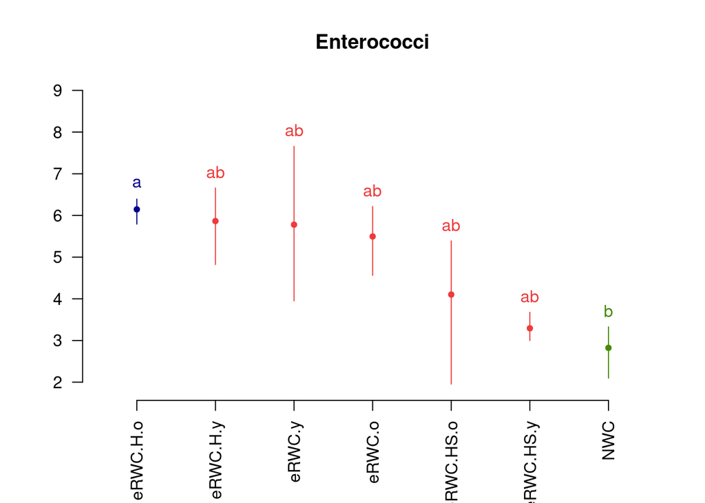

```
##   Tukey multiple comparisons of means
##     95% family-wise confidence level
##
## Fit: aov(formula = CFU_mL ~ sample)
##
## $sample
##                             diff       lwr       upr     p adj
## eRWC.H.y-eRWC.H.o   -1.264466193 -5.651305  3.122373 0.9494909
## eRWC.HS.o-eRWC.H.o  -1.442574233 -5.829413  2.944265 0.9105900
## eRWC.HS.y-eRWC.H.o  -3.117058388 -7.503898  1.269781 0.2572630
## eRWC.o-eRWC.H.o     -0.007373058 -4.394212  4.379466 1.0000000
## eRWC.y-eRWC.H.o     -1.559289033 -5.946128  2.827550 0.8776525
## NWC-eRWC.H.o        -4.526231162 -8.913070 -0.139392 0.0411874
## eRWC.HS.o-eRWC.H.y  -0.178108041 -4.564947  4.208731 0.9999991
## eRWC.HS.y-eRWC.H.y  -1.852592195 -6.239431  2.534247 0.7717983
## eRWC.o-eRWC.H.y      1.257093135 -3.129746  5.643932 0.9508071
## eRWC.y-eRWC.H.y     -0.294822841 -4.681662  4.092016 0.9999825
## NWC-eRWC.H.y        -3.261764969 -7.648604  1.125074 0.2172994
## eRWC.HS.y-eRWC.HS.o -1.674484155 -6.061323  2.712355 0.8396806
## eRWC.o-eRWC.HS.o     1.435201176 -2.951638  5.822040 0.9124744
## eRWC.y-eRWC.HS.o    -0.116714800 -4.503554  4.270124 0.9999999
## NWC-eRWC.HS.o       -3.083656929 -7.470496  1.303182 0.2672361
## eRWC.o-eRWC.HS.y     3.109685330 -1.277154  7.496524 0.2594401
## eRWC.y-eRWC.HS.y     1.557769355 -2.829070  5.944608 0.8781182
## NWC-eRWC.HS.y       -1.409172774 -5.796012  2.977666 0.9189370
## eRWC.y-eRWC.o       -1.551915976 -5.938755  2.834923 0.8799031
## NWC-eRWC.o          -4.518858104 -8.905697 -0.132019 0.0416135
## NWC-eRWC.y          -2.966942129 -7.353781  1.419897 0.3043144
```

```
## Staphylococci
```

```
##
##  Bartlett test of homogeneity of variances
##
## data:  Staphylococci
## Bartlett's K-squared = 6.3221, df = 6, p-value = 0.3881
```

```
##             Df Sum Sq Mean Sq F value Pr(>F)
## sample       6   29.4   4.901   3.965 0.0158 *
## Residuals   14   17.3   1.236
## ---
## Signif. codes:  0 '***' 0.001 '**' 0.01 '*' 0.05 '.' 0.1 ' ' 1
```

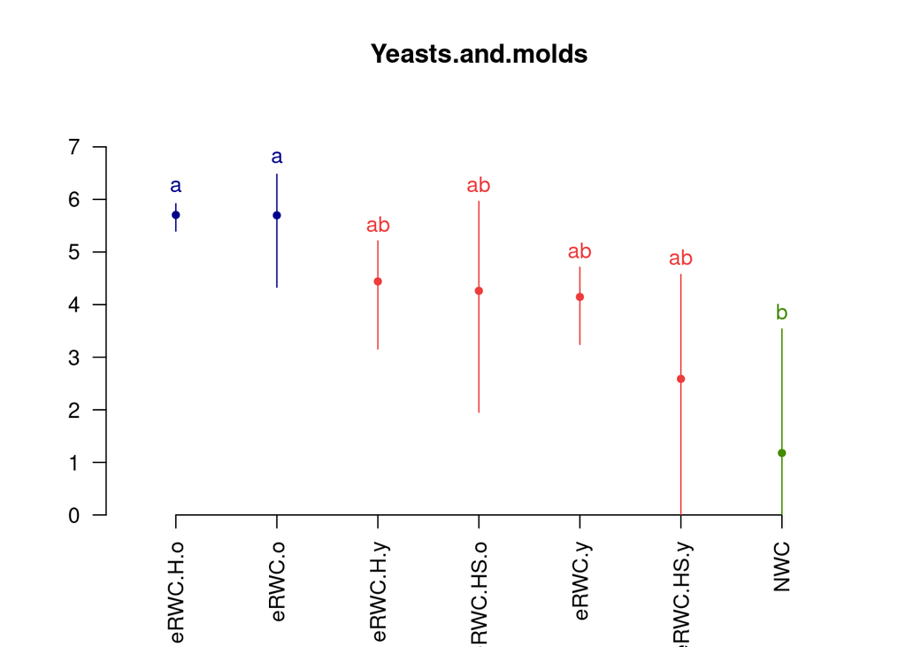

```
##   Tukey multiple comparisons of means
##     95% family-wise confidence level
##
## Fit: aov(formula = CFU_mL ~ sample)
##
## $sample
##                           diff        lwr        upr     p adj
## eRWC.H.y-eRWC.H.o    2.2577275 -0.8416620  5.3571170 0.2349343
## eRWC.HS.o-eRWC.H.o  -1.7374481 -4.8368376  1.3619414 0.5027973
## eRWC.HS.y-eRWC.H.o  -0.3140636 -3.4134532  2.7853259 0.9998070
## eRWC.o-eRWC.H.o     -0.1088761 -3.2082657  2.9905134 0.9999996
## eRWC.y-eRWC.H.o      0.7616601 -2.3377294  3.8610496 0.9761075
## NWC-eRWC.H.o        -0.9986391 -4.0980286  2.1007504 0.9178924
## eRWC.HS.o-eRWC.H.y  -3.9951756 -7.0945652 -0.8957861 0.0083527
## eRWC.HS.y-eRWC.H.y  -2.5717911 -5.6711807  0.5275984 0.1360737
## eRWC.o-eRWC.H.y     -2.3666037 -5.4659932  0.7327859 0.1955352
## eRWC.y-eRWC.H.y     -1.4960674 -4.5954569  1.6033221 0.6569113
## NWC-eRWC.H.y        -3.2563666 -6.3557561 -0.1569771 0.0366836
## eRWC.HS.y-eRWC.HS.o  1.4233845 -1.6760051  4.5227740 0.7028500
## eRWC.o-eRWC.HS.o     1.6285720 -1.4708176  4.7279615 0.5717119
## eRWC.y-eRWC.HS.o     2.4991082 -0.6002813  5.5984977 0.1550668
## NWC-eRWC.HS.o        0.7388090 -2.3605805  3.8381985 0.9794171
## eRWC.o-eRWC.HS.y     0.2051875 -2.8942020  3.3045770 0.9999840
## eRWC.y-eRWC.HS.y     1.0757237 -2.0236658  4.1751133 0.8886383
## NWC-eRWC.HS.y       -0.6845755 -3.7839650  2.4148141 0.9859347
## eRWC.y-eRWC.o        0.8705362 -2.2288533  3.9699258 0.9550925
## NWC-eRWC.o          -0.8897630 -3.9891525  2.2096266 0.9504049
## NWC-eRWC.y          -1.7602992 -4.8596887  1.3390903 0.4886678
```

```
## Enterobacteriaceae
```

```
##
##  Bartlett test of homogeneity of variances
##
## data:  Enterobacteriaceae
## Bartlett's K-squared = 2.7228, df = 6, p-value = 0.8427
```

```
##             Df Sum Sq Mean Sq F value Pr(>F)
## sample       6  50.14   8.357   3.368 0.0287 *
## Residuals   14  34.74   2.482
## ---
## Signif. codes:  0 '***' 0.001 '**' 0.01 '*' 0.05 '.' 0.1 ' ' 1
```

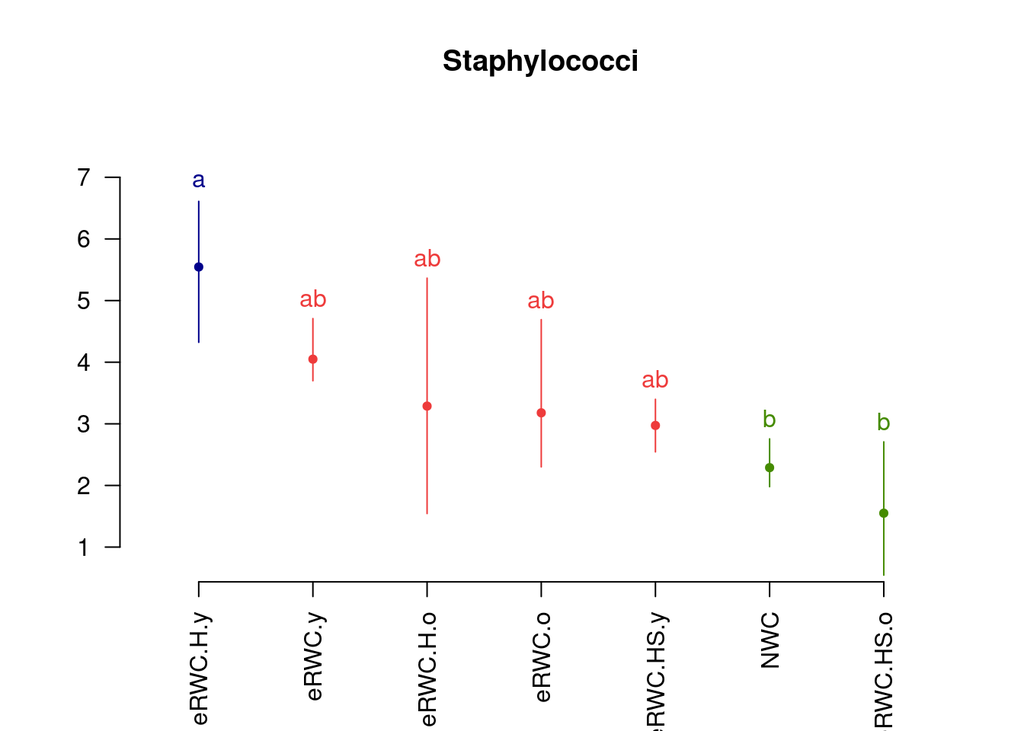

```
##   Tukey multiple comparisons of means
##     95% family-wise confidence level
##
## Fit: aov(formula = CFU_mL ~ sample)
##
## $sample
##                            diff       lwr          upr     p adj
## eRWC.H.y-eRWC.H.o    1.21248499 -3.179522  5.604492081 0.9585151
## eRWC.HS.o-eRWC.H.o  -1.58228721 -5.974294  2.809719879 0.8710773
## eRWC.HS.y-eRWC.H.o  -2.06572471 -6.457732  2.326282379 0.6812679
## eRWC.o-eRWC.H.o      1.18780958 -3.204198  5.579816665 0.9622874
## eRWC.y-eRWC.H.o     -0.46109591 -4.853103  3.930911180 0.9997632
## NWC-eRWC.H.o        -3.21047179 -7.602479  1.181535292 0.2318928
## eRWC.HS.o-eRWC.H.y  -2.79477220 -7.186779  1.597234885 0.3664833
## eRWC.HS.y-eRWC.H.y  -3.27820970 -7.670217  1.113797384 0.2140684
## eRWC.o-eRWC.H.y     -0.02467542 -4.416683  4.367331671 1.0000000
## eRWC.y-eRWC.H.y     -1.67358090 -6.065588  2.718426186 0.8406891
## NWC-eRWC.H.y        -4.42295679 -8.814964 -0.030949702 0.0479018
## eRWC.HS.y-eRWC.HS.o -0.48343750 -4.875445  3.908569587 0.9996890
## eRWC.o-eRWC.HS.o     2.77009679 -1.621910  7.162103873 0.3758113
## eRWC.y-eRWC.HS.o     1.12119130 -3.270816  5.513198389 0.9712887
## NWC-eRWC.HS.o       -1.62818459 -6.020192  2.763822501 0.8562009
## eRWC.o-eRWC.HS.y     3.25353429 -1.138473  7.645541374 0.2204311
## eRWC.y-eRWC.HS.y     1.60462880 -2.787378  5.996635889 0.8639396
## NWC-eRWC.HS.y       -1.14474709 -5.536754  3.247260001 0.9682985
## eRWC.y-eRWC.o       -1.64890548 -6.040913  2.743101603 0.8492166
## NWC-eRWC.o          -4.39828137 -8.790288 -0.006274285 0.0495677
## NWC-eRWC.y          -2.74937589 -7.141383  1.642631199 0.3837524
```

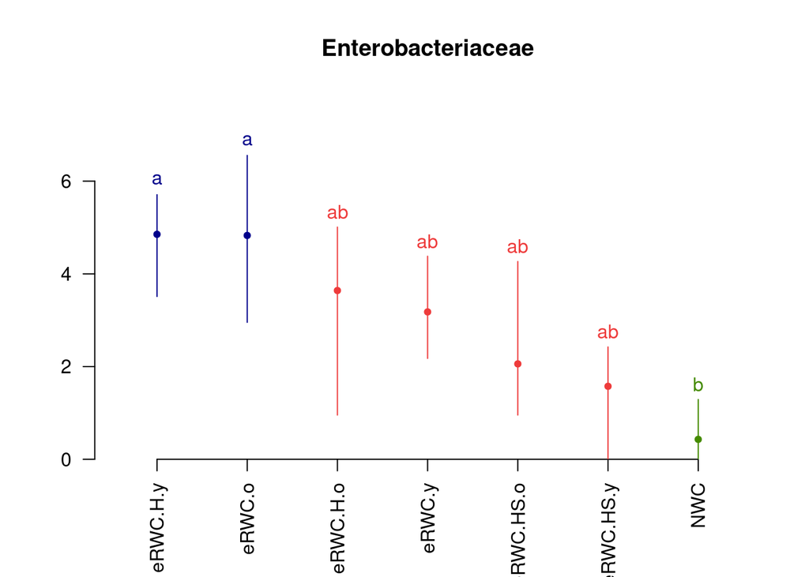

# 16S rRNA gene amplicon sequencing - cultures

This R script will analyze 16S results from ASV counts to graphical visualization mainly using phyloseq http://joey711.github.io/phyloseq/import-data.html

## Cultures

```r
# import raw sequences that were already quality filtered as described in Dreier et al 2022
fp <- file.path(getwd(), "..", "data", "cultures", "ngs", "ASV_table.xlsx")
cult_physeq <- load_ngs_data(fp)
```

```r
# Counts to relative abundance
# ASV counts transformed to relative abundance (%)
# Note: raw sequences were already quality filtered as described in Dreier et al 2022
# thus taxa are not further trimmed for ordination and diversity analysis
# since even low abundant species are informative
cult_physeqR  = transform_sample_counts(cult_physeq, function(x) x/sum(x)*100 )
```

```r
# font sizes for plots
yaxis_tick_label_size = 10
yaxis_label_size = 10

title_size = 14
subtitle_size = 14
xaxis_tick_label_size = 12
```

### Diversity

```r
# Summarize diversity values in table
metadata <- as(sample_data(cult_physeq), "data.frame")
richness_table <- estimate_richness(cult_physeq)
richness_table["Sample"] <- metadata["sample_subtype"]
richness_table["replicate"] <- metadata["replicate"]
# Reorder columns
richness_table <- richness_table[, c(10, 11, 1, 2, 3, 4, 5, 6, 7, 8 , 9)]
richness_table
```

```
##                Sample replicate Observed    Chao1  se.chao1       ACE    se.ACE
## RM.2               RM         1      187 187.3333 0.9257269 187.45666 5.5240883
## NWC.2             NWC         1        8   8.0000 0.0000000   8.00000 1.2247449
## eRM.2             eRM         1       33  33.0000 0.2461830  33.38948 2.2959662
## eRM.H.2         eRM.H         1       27  27.0000 0.0000000  27.00000 1.6329932
## eRM.HS.2       eRM.HS         1       63  63.0000 0.0000000  63.00000 3.7838420
## eRWC.y.2       eRWC.y         1       19  19.0000 0.0000000  19.00000 1.3377121
## eRWC.H.y.2   eRWC.H.y         1       27  27.0000 0.1635511  27.57143 1.6471079
## eRWC.HS.y.2 eRWC.HS.y         1       13  13.0000 0.0000000  13.00000 1.3008873
## eRWC.o.2       eRWC.o         1       27  27.0000 0.0000000  27.00000 2.0184336
## eRWC.H.o.2   eRWC.H.o         1       29  29.0000 0.4913037  29.32346 2.1534176
## eRWC.HS.o.2 eRWC.HS.o         1       19  19.0000 0.0000000  19.00000 1.3377121
## RM.3               RM         2      178 178.0000 0.0000000 178.00000 2.2044388
## NWC.3             NWC         2       12  12.0000 0.0000000  12.00000 0.9574271
## eRM.3             eRM         2       25  25.0000 0.4898979  25.22141 2.1781484
## eRM.H.3         eRM.H         2       34  34.0000 0.1641974  34.65021 1.7217992
## eRM.HS.3       eRM.HS         2       38  38.0000 0.0000000  38.00000 2.7956733
## eRWC.y.3       eRWC.y         2       30  30.0000 0.2457980  30.66233 2.2014708
## eRWC.H.y.3   eRWC.H.y         2       24  25.0000 2.3108440  24.96505 2.2482432
## eRWC.HS.y.3 eRWC.HS.y         2       22  22.0000 0.1221261  22.71096 2.2389837
## eRWC.o.3       eRWC.o         2       31  31.0000 0.0000000  31.00000 1.6461098
## eRWC.H.o.3   eRWC.H.o         2       21  21.0000 0.0000000  21.00000 1.7994708
## eRWC.HS.o.3 eRWC.HS.o         2       25  25.0000 0.0000000  25.00000 1.3564660
## RM.4               RM         3      125 125.0000 0.4979960 125.18280 4.3009922
## NWC.4             NWC         3        9   9.0000 0.0000000   9.00000 0.9428090
## eRM.4             eRM         3       31  31.0000 0.4918694  31.51953 1.6129265
## eRM.H.4         eRM.H         3       48  48.0000 0.0000000  48.00000 0.9895285
## eRM.HS.4       eRM.HS         3       40  40.0000 0.4937104  40.25598 2.1854976
## eRWC.y.4       eRWC.y         3       30  30.0000 0.0000000  30.00000 2.5099801
## eRWC.H.y.4   eRWC.H.y         3       26  26.0000 0.0000000  26.00000 2.4806947
## eRWC.HS.y.4 eRWC.HS.y         3       18  19.0000 2.2998856  18.74896 2.0054355
## eRWC.o.4       eRWC.o         3       28  28.0000 0.0000000  28.00000 1.8516402
## eRWC.H.o.4   eRWC.H.o         3       25  25.0000 0.2449490  25.51689 2.1424747
## eRWC.HS.o.4 eRWC.HS.o         3       23  23.0000 0.0000000  23.00000 1.8177865
##               Shannon    Simpson InvSimpson     Fisher
## RM.2        3.6340335 0.90893777  10.981501 28.4912451
## NWC.2       0.2132335 0.08356654   1.091187  0.6995682
## eRM.2       1.7778360 0.75780040   4.128826  3.6674951
## eRM.H.2     2.1073510 0.82641140   5.760747  2.9650366
## eRM.HS.2    0.8408825 0.32036464   1.471377  6.3968941
```

[output cut: 13 more lines]

```
## eRWC.HS.y.3 0.5881647 0.26935073   1.368646  1.9181873
## eRWC.o.3    1.5189914 0.68263234   3.150920  2.8420564
## eRWC.H.o.3  1.1320277 0.47805487   1.915910  1.8527952
## eRWC.HS.o.3 1.5286237 0.71463170   3.504243  2.2253392
## RM.4        2.3087924 0.78350260   4.618993 13.9592564
## NWC.4       0.2276936 0.08177288   1.089055  0.7896196
## eRM.4       0.4034391 0.12115649   1.137859  3.0807798
## eRM.H.4     2.1397921 0.78753973   4.706762  4.6158258
## eRM.HS.4    0.8119889 0.30681802   1.442623  3.7345737
## eRWC.y.4    0.2836259 0.09028779   1.099249  2.9459226
## eRWC.H.y.4  0.3643399 0.12334999   1.140706  2.5463340
## eRWC.HS.y.4 0.3116122 0.11367379   1.128253  1.6641025
## eRWC.o.4    0.4497640 0.14913289   1.175272  2.7356668
## eRWC.H.o.4  0.4514010 0.15689793   1.186096  2.4200027
## eRWC.HS.o.4 0.5752884 0.23815353   1.312600  2.1386689
```

```r
# write to excel
write.xlsx(richness_table, '../tables/cultures_richness_table.xlsx', colNames = TRUE, rowNames = TRUE, asTable = FALSE, keepNA = FALSE, na.string = "NaN")

# Beta diversity Permanova for all samples
adonis2(distance(cult_physeq, method="bray") ~ sample_subtype, data = metadata, permutations = 9999)
```

```
## Permutation test for adonis under reduced model
## Terms added sequentially (first to last)
## Permutation: free
## Number of permutations: 9999
##
## adonis2(formula = distance(cult_physeq, method = "bray") ~ sample_subtype, data = metadata, permutations = 9999)
##                Df SumOfSqs      R2      F Pr(>F)
## sample_subtype 10   5.1665 0.41167 1.5394 0.0178 *
## Residual       22   7.3837 0.58833
## Total          32  12.5502 1.00000
## ---
## Signif. codes:  0 '***' 0.001 '**' 0.01 '*' 0.05 '.' 0.1 ' ' 1
```

```r
# filter for cultures
cultures_only_phy <- subset_samples(cult_physeq, sample_type == "eRWC")
# cultures metadata
c_metadata <- as(sample_data(cultures_only_phy), "data.frame")
# Beta diversity Permanova
adonis2(distance(cultures_only_phy, method="bray") ~ sample_subtype, data = c_metadata, permutations = 9999)
```

```
## Permutation test for adonis under reduced model
## Terms added sequentially (first to last)
## Permutation: free
## Number of permutations: 9999
##
## adonis2(formula = distance(cultures_only_phy, method = "bray") ~ sample_subtype, data = c_metadata, permutations = 9999)
##                Df SumOfSqs      R2      F Pr(>F)
## sample_subtype  5   1.1375 0.23204 0.7252 0.7083
## Residual       12   3.7647 0.76796
## Total          17   4.9022 1.00000
```

### Diversity plot

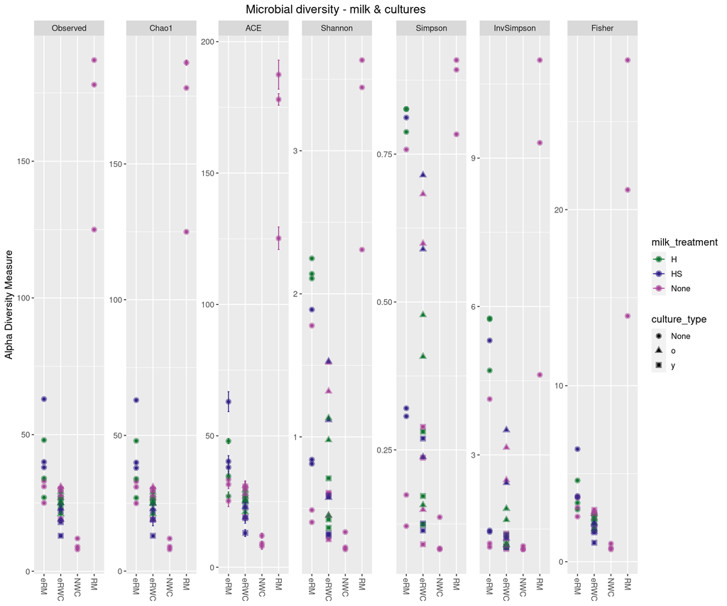

### Relative abundances

```r
# percentage thresholds used for filtering
abund_thresh <- 1.0
sp_res_th <- 0.6

# Taxa agglomeration----
# Differently to Ord. & Div. plots, in bar charts a taxa filter is necessary to show the most abundant species
# Let's agglomerate at the Species level using the tax_glom function from phyloseq
# It requires "Kingdom" to be the first column of our tax_table
# (see probl. solved https://github.com/joey711/phyloseq/issues/1551)
tax_table(cult_physeqR) <- tax_table(cult_physeqR)[,c(2:10,1)] # Re-order the columns

# Let's agglomerate at the Species level
# i.e. different ASV belonging to the same species will be agglomerated
# their relative abundance will be summed
# further the data frame is melted to long format for filtering and plotting
cult_physeqR_tax <- cult_physeqR %>%
  tax_glom(taxrank = "Species") %>%
  psmelt()

# Select only the natural whey and the enriched raw milk-whey culture samples
cult_physeqR_tax_samples = subset(cult_physeqR_tax, sample_type %in% c("eRWC", "NWC"))

# create a mapper to replace old lactobacilli names in table
fp = file.path(getwd(), "..", "data", "species_dict.json")
species_dict <- fromJSON(file = fp, simplify = TRUE)

# In order to get groups in the plots add a group category and rename replicates
cult_physeqR_tax_samples <- cult_physeqR_tax_samples %>%
  mutate(sample_subtype = substr(sample_ID, 1, nchar(sample_ID) - 2))  %>%
  mutate(replicate = replicate - 1)

# For plotting it looks nicer when the species names are separated by spaces
cult_physeqR_tax_samples <- cult_physeqR_tax_samples %>%
    mutate(Species = str_replace(Species, "_", " ")) %>%
    # update new lactobacilli names
    mutate(Species = recode_factor(Species, !!!species_dict)) %>%
    # change Species to sp. for unknown species names
    mutate(Species = str_replace(Species, "Species", "sp."))

# group data frame by Species, calculate mean rel. abundance
means <- ddply(cult_physeqR_tax_samples, ~Species, function(x) c(mean = mean(x$Abundance)))

# get the species names with high and low average relative abundance, respectively
# Species whose rel. abundance is higher than 1% (or threshold [abund_thresh] defined above)
high_ab_sp <- means[means$mean >= abund_thresh, "Species"]
# Species whose rel. abundance is less than 1%
low_ab_sp <- means[means$mean < abund_thresh, "Species"]

# Create two data frames with high and low avg. abundances
cult_physeqR_tax_high <- cult_physeqR_tax_samples[cult_physeqR_tax_samples$Species %in% high_ab_sp,]
cult_physeqR_tax_low <- cult_physeqR_tax_samples[cult_physeqR_tax_samples$Species %in% low_ab_sp,]

low_abund <- cult_physeqR_tax_low
lowabund_str <- paste(c("<", abund_thresh, "% avg. abundance"), collapse = " ")
low_abund$Species <- lowabund_str
cult_physeqR_tax_high_full <- rbind(cult_physeqR_tax_high, low_abund)


# convert Species to a character vector from a factor because R
cult_physeqR_tax_low$Species <- as.character(cult_physeqR_tax_low$Species)

# group data frame by Species, calculate max rel. abundance
maxs <- ddply(cult_physeqR_tax_low, ~Species, function(x) c(max = max(x$Abundance)))

# find Species whose max. abundance is less than 0.6% [threshold "sp_res_th" defined above]
remainder <- maxs[maxs$max <= sp_res_th,]$Species

# change their name to "Other species"
cult_physeqR_tax_low[cult_physeqR_tax_low$Species %in% remainder,]$Species <- 'Other species'
```

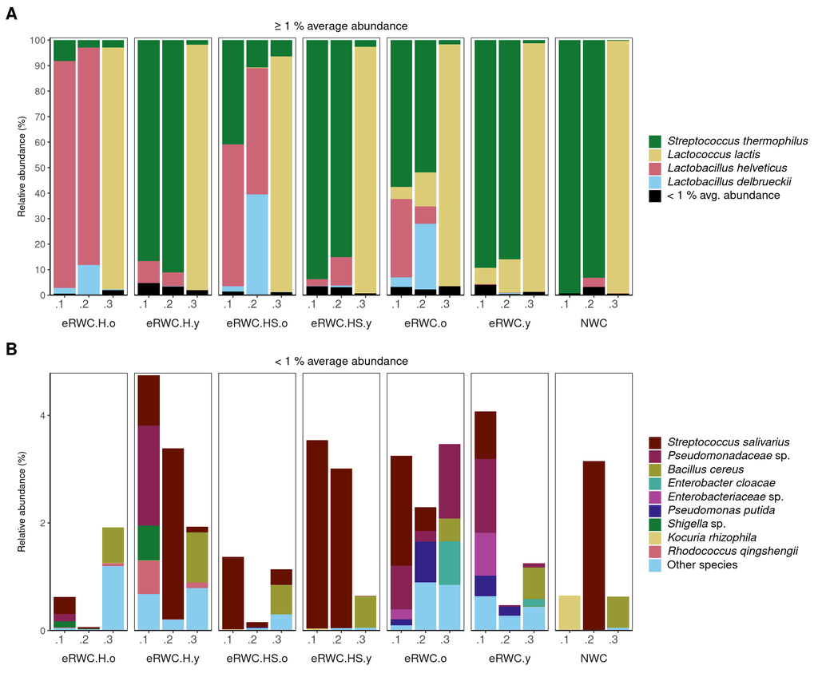

```r
# create nicely formatted guides with the species names
ordered_species_list <- ordered_species_guides(cult_physeqR_tax_low$Species, "Other species")
ordered_species <- ordered_species_list[[1]]
ordered_sp_labels <- ordered_species_list[[2]]

ha_ordered_species_list <- ordered_species_guides(cult_physeqR_tax_high$Species, lowabund_str)
ha_ordered_species <- ha_ordered_species_list[[1]]
ha_ordered_sp_labels <- ha_ordered_species_list[[2]]

# sample_ID levels
sampleid_vector <- c("NWC.2", "NWC.3", "NWC.4",
                     "eRWC.y.2", "eRWC.y.3", "eRWC.y.4",
                     "eRWC.o.2", "eRWC.o.3", "eRWC.o.4",
                     "eRWC.H.y.2", "eRWC.H.y.3", "eRWC.H.y.4",
                     "eRWC.H.o.2", "eRWC.H.o.3", "eRWC.H.o.4",
                     "eRWC.HS.y.2", "eRWC.HS.y.3", "eRWC.HS.y.4",
                     "eRWC.HS.o.2", "eRWC.HS.o.3", "eRWC.HS.o.4")

# Colors are set manually
species_colors <- c("#88CCEE", "#CC6677", "#DDCC77", "#117733", "#332288", "#AA4499",
                    "#44AA99", "#999933", "#882255", "#661100", "#6699CC", "#888888")

# Define font size for both plots here
yaxis_tick_label_size = 10
yaxis_label_size = 10
xaxis_tick_label_size = 12
Xaxis_rot = 0
df_sorter = c("Species", "sample_subtype")
x_labels = c(".1",".2",".3")

# High abundant species plot
p1 <- draw_ha_stacked_plot(df = cult_physeqR_tax_high_full,
                           sampleid_vector = sampleid_vector,
                           x_factor = "sample_ID",
                           x_labels = x_labels,
                           species_colors = species_colors,
                           df_sorter = df_sorter,
                           wrap_group = c("~sample_subtype"),
                           ordered_sp_labels = ha_ordered_sp_labels,
                           abund_thresh = abund_thresh,
                           sp_res_th = sp_res_th,
                           ordered_species = ha_ordered_species
                           )

# Low abundant species plot
p2 <- draw_la_stacked_plot(df = cult_physeqR_tax_low,
                           sampleid_vector = sampleid_vector,
                           x_labels = x_labels,
                           species_colors = species_colors,
                           ordered_sp_labels = ordered_sp_labels,
                           x_factor = "sample_ID",
                           ordered_species = ordered_species,
                           wrap_group = c("~sample_subtype"),
                           abund_thresh = abund_thresh,
                           sp_res_th = sp_res_th
                           )
```

# 16S rRNA gene amplicon sequencing - cheese

This R script will analyze 16S results from ASV counts to graphical visualization mainly using phyloseq http://joey711.github.io/phyloseq/import-data.html

## Cheese

```r
cheese_fp <- file.path(getwd(), "..", "data", "cheese", "ngs", "ASV_table.xlsx")
cheese_physeq = load_ngs_data(cheese_fp)
# remove thermized controls
cheese_physeq = subset_samples(cheese_physeq, sample_ID != "K302_DNA" & sample_ID != "K310_DNA")
# since we removed the thermized sample, there may be taxa with count = 0
# this will eventually remove them
cheese_physeq <- prune_taxa(taxa_sums(cheese_physeq) > 1, cheese_physeq)
```

```r
# get relative abundance data
cheese_physeqR <- transform_sample_counts(cheese_physeq, function(x) x/sum(x)*100 )
```

```r
# font sizes for plots
yaxis_tick_label_size = 10
yaxis_label_size = 10

title_size = 14
subtitle_size = 14
xaxis_tick_label_size = 12
```

### Distance Ordination Analysis

#### Cultures

```r
# bray = "Bray-Curtis dissimilarity"
# NMDS = Non-metric Multidimensional Scaling
# import raw sequences that were already quality filtered as described in Dreier et al 2022
fp_culture <- file.path(getwd(), "..", "data", "cultures", "ngs", "ASV_table.xlsx")
cult_physeq <- load_ngs_data(fp_culture)
cult_physeqR  = transform_sample_counts(cult_physeq, function(x) x/sum(x)*100 )
ordi = ordinate(cult_physeqR, method = "NMDS", distance = "bray")
```

```
## Square root transformation
## Wisconsin double standardization
## *** Best solution was not repeated -- monoMDS stopping criteria:
##      1: no. of iterations >= maxit
##     17: stress ratio > sratmax
##      2: scale factor of the gradient < sfgrmin
```

```r
dnmds_plt <- plot_ordination(cult_physeqR, ordi, "sample_ID", color = "sample_type")
# replace Na with "None" in milk_treatment factor
NMDS_df <- dnmds_plt$data %>% replace_na(list(milk_treatment = "None"))
# plot with all the sample_types
cult_p_ord <- ggplot(NMDS_df,
                 aes(NMDS1, NMDS2,
                     color = milk_treatment,
                     shape = sample_type)) +
          geom_point(size = 6) +
          scale_color_manual(values = c("H" = "#117733",
                                        "HS" = "#332288",
                                        "None" = "#AA4499")) +
          labs(title = "NMDS (Bray-Curtis), milk & cultures") +
          guides(color = guide_legend(order = 1),
                 shape = guide_legend(order = 2)) +
          theme(text = element_text(size = xaxis_tick_label_size),
                plot.title = element_text(size = title_size, hjust = 0.5, )) +
          geom_text(mapping = aes(label = culture_type), color = 001,
                    vjust = 0, hjust = 1.5, size = xaxis_tick_label_size/2)
```

#### Cheese

```r
# bray = "Bray-Curtis dissimilarity"
# NMDS = Non-metric MultiDimentional Scaling
ordi = ordinate(cheese_physeqR, method = "NMDS", distance = "bray")
```

```
## Square root transformation
## Wisconsin double standardization
## *** Best solution repeated 10 times
```

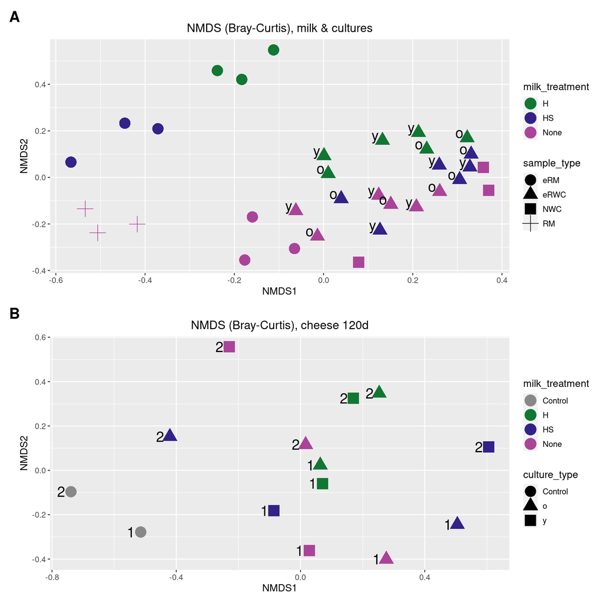

```r
dnmds_plt <- plot_ordination(cheese_physeqR, ordi, "sample_ID", color = "milk_treatment")

NMDS_df <- dnmds_plt$data
# plot with all the sample_types
ch_p_ord = ggplot(NMDS_df,
                  aes(NMDS1, NMDS2,
                      color = milk_treatment,
                      shape = culture_type)) +
                  geom_point(size = 6) +
                  scale_color_manual(values = c("H" = "#117733",
                                                "HS" = "#332288",
                                                "None" = "#AA4499",
                                                "Control" = "#888888")) +
                  labs(title = "NMDS (Bray-Curtis), cheese 120d") +
                  guides(color = guide_legend(order = 1),
                         shape = guide_legend(order = 2)) +
                  theme(text = element_text(size = xaxis_tick_label_size),
                        plot.title = element_text(size = title_size, hjust = 0.5)) +
                  geom_text(mapping = aes(label = production_day), color = 001,
                          vjust = 0.5, hjust = 1.75, size = xaxis_tick_label_size/2)
```

### Diversity

```r
# Diversity parameters plot----
# Summarize alpha-diversity values in table
metadata <- as(sample_data(cheese_physeq), "data.frame")
richness_table <- estimate_richness(cheese_physeq)
richness_table["Adjunct culture"] <- metadata["AdjunctCulture"]
richness_table["Production day"] <- metadata["production_day"]
# Reorder columns
richness_table <- richness_table[, c(10, 11, 1, 2, 3, 4, 5, 6, 7, 8 , 9)]
richness_table
```

```
##          Adjunct culture Production day Observed Chao1  se.chao1      ACE
## K301_DNA         Control              1       25    25 0.0000000 25.00000
## K303_DNA          eRWC.y              1       23    23 0.4890096      NaN
## K304_DNA        eRWC.H.y              1       27    27 0.4906534 27.54519
## K305_DNA       eRWC.HS.y              1       25    25 0.4898979 25.62109
## K306_DNA          eRWC.o              1       24    24 0.0000000 24.00000
## K307_DNA        eRWC.H.o              1       28    28 0.4909903 28.34823
## K308_DNA       eRWC.HS.o              1       27    27 0.2453267 28.05837
## K309_DNA         Control              2       18    18 0.0000000 18.00000
## K311_DNA          eRWC.y              2       20    20 0.0000000 20.00000
## K312_DNA        eRWC.H.y              2       29    29 0.0000000 29.00000
## K313_DNA       eRWC.HS.y              2       24    24 0.0000000 24.00000
## K314_DNA          eRWC.o              2       27    27 0.0000000 27.00000
## K315_DNA        eRWC.H.o              2       27    27 0.0000000 27.00000
## K316_DNA       eRWC.HS.o              2       24    24 0.0000000 24.00000
##            se.ACE  Shannon   Simpson InvSimpson   Fisher
## K301_DNA 2.000000 1.523419 0.6485980   2.845743 2.522969
## K303_DNA      NaN 1.294502 0.6385605   2.766715 2.136409
## K304_DNA 1.408130 1.461295 0.7130358   3.484755 2.555412
## K305_DNA 1.436585 1.467699 0.7218074   3.594632 2.307830
## K306_DNA 1.620185 1.366634 0.6789691   3.114965 2.203134
## K307_DNA 1.939789 1.491580 0.6977966   3.309029 2.723312
## K308_DNA 1.953896 1.440837 0.6901837   3.227719 2.566512
## K309_DNA 1.581139 1.071967 0.4649089   1.868841 1.687209
## K311_DNA 1.788854 1.195255 0.5412021   2.179609 1.881448
## K312_DNA 1.856953 1.689331 0.7426990   3.886499 2.712114
## K313_DNA 1.620185 1.547118 0.7358553   3.785803 2.204451
## K314_DNA 1.632993 1.322028 0.6130468   2.584292 2.561010
## K315_DNA 1.360828 1.732635 0.7466947   3.947805 2.638525
## K316_DNA 1.825742 1.352408 0.6385323   2.766499 2.293975
```

```r
# write to excel
write.xlsx(richness_table, '../tables/cheese_richness_table.xlsx', colNames = TRUE, rowNames = TRUE, asTable = FALSE, keepNA = FALSE, na.string = "NaN")

# Beta diversity Permanova
adonis2(distance(cheese_physeq, method="bray") ~ AdjunctCulture, data = metadata, permutations = 9999)
```

```
## Permutation test for adonis under reduced model
## Terms added sequentially (first to last)
## Permutation: free
## Number of permutations: 9999
##
## adonis2(formula = distance(cheese_physeq, method = "bray") ~ AdjunctCulture, data = metadata, permutations = 9999)
##                Df SumOfSqs      R2      F Pr(>F)
## AdjunctCulture  6  0.67595 0.63871 2.0625 0.0393 *
## Residual        7  0.38236 0.36129
## Total          13  1.05830 1.00000
## ---
## Signif. codes:  0 '***' 0.001 '**' 0.01 '*' 0.05 '.' 0.1 ' ' 1
```

### Diversity plot

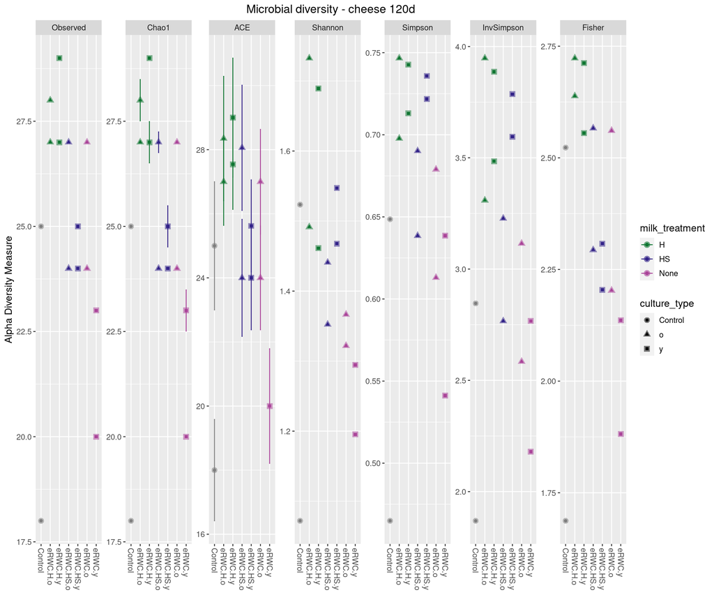

### Relative abundances

```r
# percentage thresholds used for filtering
abund_thresh <- 1.0
sp_res_th <- 0.6

# Taxa agglomeration----
# Differently to Ord. & Div. plots, in bar charts a taxa filter is necessary to show the most abundant species
# Let's agglomerate at the Species level using the tax_glom function from phyloseq
# It requires "Kingdom" to be the first column of our tax_table
# (see probl. solved https://github.com/joey711/phyloseq/issues/1551)
tax_table(cheese_physeqR) <- tax_table(cheese_physeqR)[,c(2:10,1)] # Re-order the columns


# Let's agglomerate at the Species level
# i.e. different ASV belonging to the same species will be agglomerated
# their relative abundance will be summed
# further the data frame is melted to long format for filtering and plotting
ch_physeqR_tax <- cheese_physeqR %>%
  tax_glom(taxrank = "Species") %>%
  psmelt()

# Select only the natural whey and the enriched raw milk-whey culture samples
ch_physeqR_tax_samples <- ch_physeqR_tax

# create a mapper to replace old lactobacilli names in table
fp = file.path(getwd(), "..", "data", "species_dict.json")
species_dict <- fromJSON(file = fp, simplify = TRUE)

# In order to get groups in the plots add a group category and rename replicates # Cultures only
ch_physeqR_tax_samples <- ch_physeqR_tax_samples %>%
  mutate(SubExperiment = paste("Day", substr(SubExperiment, nchar(SubExperiment), nchar(SubExperiment))))

# For plotting it looks nicer when the species names are separated by spaces
ch_physeqR_tax_samples <- ch_physeqR_tax_samples %>%
    mutate(Species = str_replace(Species, "_", " ")) %>%
    # update new lactobacilli names
    mutate(Species = recode_factor(Species, !!!species_dict)) %>%
    # change Species to sp. for unknown species names
    mutate(Species = str_replace(Species, "Species", "sp."))

# group data frame by Species, calculate mean rel. abundance
ch_means <- ddply(ch_physeqR_tax_samples, ~Species, function(x) c(mean = mean(x$Abundance)))

# get the species names with high and low average relative abundance, respectively
# Species whose rel. abundance is higher than 1% (or threshold [abund_thresh] defined above)
ch_high_ab_sp <- ch_means[ch_means$mean >= abund_thresh, "Species"]
# Species whose rel. abundance is less than 1%
ch_low_ab_sp <- ch_means[ch_means$mean < abund_thresh, "Species"]

# Create two data frames with high and low avg. abundances
ch_physeqR_tax_high <- ch_physeqR_tax_samples[ch_physeqR_tax_samples$Species %in% ch_high_ab_sp,]
ch_physeqR_tax_low <- ch_physeqR_tax_samples[ch_physeqR_tax_samples$Species %in% ch_low_ab_sp,]
low_abund <- ch_physeqR_tax_low

lowabund_str <- paste(c("<", abund_thresh, "% avg. abundance"), collapse = " ")

low_abund$Species <- lowabund_str

ch_physeqR_tax_high_full <- rbind(ch_physeqR_tax_high, low_abund)

# convert Species to a character vector from a factor because R
ch_physeqR_tax_low$Species <- as.character(ch_physeqR_tax_low$Species)

# group data frame by Species, calculate max rel. abundance
ch_maxs <- ddply(ch_physeqR_tax_low, ~Species, function(x) c(max = max(x$Abundance)))

# find Species whose max. abundance is less than 0.6 % [threshold "sp_res_th" defined above]
ch_remainder <- ch_maxs[ch_maxs$max <= sp_res_th,]$Species

# change their name to "Other species"
ch_physeqR_tax_low[ch_physeqR_tax_low$Species %in% ch_remainder,]$Species <- 'Other species'
```

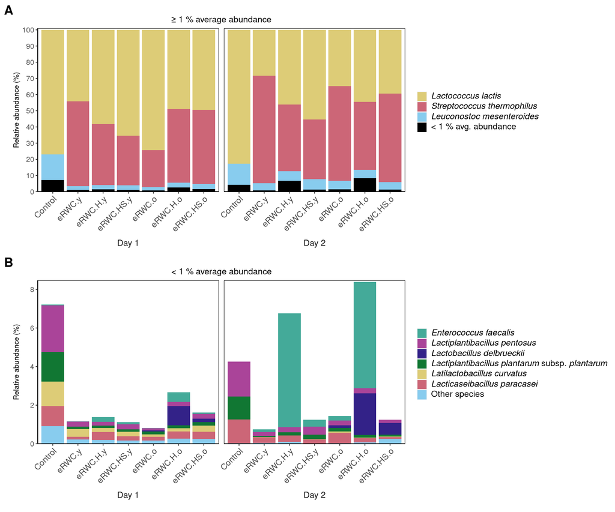

```r
# create nicely formatted guides with the species names
ordered_species_list <- ordered_species_guides(ch_physeqR_tax_low$Species, "Other species")
ordered_species <- ordered_species_list[[1]]
ordered_sp_labels <- ordered_species_list[[2]]

ha_ordered_species_list <- ordered_species_guides(ch_physeqR_tax_high$Species, lowabund_str)
ha_ordered_species <- ha_ordered_species_list[[1]]
ha_ordered_sp_labels <- ha_ordered_species_list[[2]]

# Colors are set manually
species_colors <- c("#88CCEE", "#CC6677", "#DDCC77", "#117733", "#332288", "#AA4499",
                    "#44AA99", "#999933", "#882255", "#661100", "#6699CC", "#888888")

# Define font size for both plots here
yaxis_tick_label_size = 10
yaxis_label_size = 10
xaxis_tick_label_size = 12
Xaxis_rot = 45

# sample_ID levels
sampleid_vector <- c("Control.3.1", "eRWC.y.3.1", "eRWC.H.y.3.1",
                     "eRWC.HS.y.3.1", "eRWC.o.3.1", "eRWC.H.o.3.1",
                     "eRWC.HS.o.3.1", "Control.3.2", "eRWC.y.3.2",
                     "eRWC.H.y.3.2", "eRWC.HS.y.3.2", "eRWC.o.3.2",
                     "eRWC.H.o.3.2", "eRWC.HS.o.3.2")
sample_id_labels = as.vector(sapply(sampleid_vector, FUN = function(X) substr(X, 1, nchar(X) - 4)))

# Define font size for both plots here
yaxis_tick_label_size = 10
yaxis_label_size = 10
xaxis_tick_label_size = 12
Xaxis_rot = 0
df_sorter = c("Species", "sample_subtype")
x_labels = c(".1",".2",".3")

# High abundant species plot
p3 <- draw_ha_stacked_plot(df = ch_physeqR_tax_high_full,
                           sampleid_vector = sampleid_vector,
                           x_factor = "AdjunctCulture_ID",
                           x_labels = sample_id_labels,
                           species_colors = species_colors,
                           df_sorter = df_sorter,
                           wrap_group = c("~SubExperiment"),
                           Xaxis_rot = 45,
                           ordered_sp_labels = ha_ordered_sp_labels,
                           abund_thresh = abund_thresh,
                           sp_res_th = sp_res_th,
                           ordered_species = ha_ordered_species
                           )

# Low abundant species plot
p4 <- draw_la_stacked_plot(df = ch_physeqR_tax_low,
                           sampleid_vector = sampleid_vector,
                           x_labels = sample_id_labels,
                           species_colors = species_colors,
                           ordered_sp_labels = ordered_sp_labels,
                           x_factor = "AdjunctCulture_ID",
                           ordered_species = ordered_species,
                           wrap_group = c("~SubExperiment"),
                           Xaxis_rot = 45,
                           abund_thresh = abund_thresh,
                           sp_res_th = sp_res_th
                           )
```

# Microbial counts and chemical analysis of vat milk/cheese

```r
# define paths explicitly
subset_fp <- file.path(getwd(), "..", "data", "cheese", "pivot")

meta_0d_fp <- file.path(subset_fp, "meta_microbes_0d_data.csv")
micro_0d_fp <- file.path(subset_fp, "piv_microbes_0d_data.csv")

meta_1d_fp <- file.path(subset_fp, "meta_microbes_1d_data.csv")
micro_1d_fp <- file.path(subset_fp, "piv_microbes_1d_data.csv")

meta_chem_1d_fp <- file.path(subset_fp, "meta_chem_1d_data.csv")
chem_1d_fp <- file.path(subset_fp, "piv_chem_1d_data.csv")

meta_60d_fp <- file.path(subset_fp, "meta_microbes_60d_data.csv")
micro_60d_fp <- file.path(subset_fp, "piv_microbes_60d_data.csv")

meta_120d_fp <- file.path(subset_fp, "meta_microbes_120d_data.csv")
micro_120d_fp <- file.path(subset_fp, "piv_microbes_120d_data.csv")

meta_chem_120d_fp <- file.path(subset_fp, "meta_chem_120d_data.csv")
chem_120d_fp <- file.path(subset_fp, "piv_chem_120d_data.csv")
```

### Data import and sub-setting

```r
micro_0d <- import_and_select_PCA_data(
              micro_0d_fp, meta_0d_fp,
              select_samples = c("MilkTreatment", "raw")
              )


micro_1d <- import_and_select_PCA_data(
              micro_1d_fp, meta_1d_fp,
              select_samples = c("MilkTreatment", "raw"),
              # remove the entire 304 sample due to missing measurements
              rm_samples = c("EH_304_cheese_1d")
              )


chem_1d <- import_and_select_PCA_data(
            chem_1d_fp, meta_chem_1d_fp,
            select_samples = c("MilkTreatment", "raw"),
            rm_samples = c("EH_304_cheese_1d"),
            ## remove some highly correlated features
            redundant_f = c("L.Lactic.acid.proportion.of.TLA", "Lactic.acid..total.")
            )

# make sure we don't have the meta data twice
meta_len <- length(names(read.csv(meta_chem_1d_fp))) + 1
chem_1d_data <- chem_1d[,c(1, meta_len:length(chem_1d))]

# merge chemical and microbes data
dataset_1d <- merge(micro_1d, chem_1d_data, by = "sampleID")


micro_60d <- import_and_select_PCA_data(
              micro_60d_fp, meta_60d_fp,
              select_samples = c("MilkTreatment", "raw")
              )


micro_120d <- import_and_select_PCA_data(
                micro_120d_fp, meta_120d_fp,
                select_samples = c("MilkTreatment", "raw")
                )

# remove some highly correlated features & features with NAs (Force & Fracture)
hcorr_fc <- c("L.Lactic.acid.proportion.of.TLA",
              "Lactic.acid..total.",
              "Total.volatile.carboxylic.acids",
              "Biogenic.amine",
              "Chloride",
              "Force.at.33",
              "Force.at.fracture",
              "Fracture.deformation")

chem_120d <- import_and_select_PCA_data(chem_120d_fp, meta_chem_120d_fp,
                                        select_samples = c("MilkTreatment", "raw"),
                                        redundant_f = hcorr_fc
                                        )

# make sure we don't have the meta data twice
meta_len <- length(names(read.csv(meta_chem_120d_fp))) + 1
chem_120d_data <- chem_120d[,c(1, meta_len:length(chem_120d))]

# merge chemical and microbes data
dataset_120d <- merge(micro_120d, chem_120d_data, by = "sampleID")
```

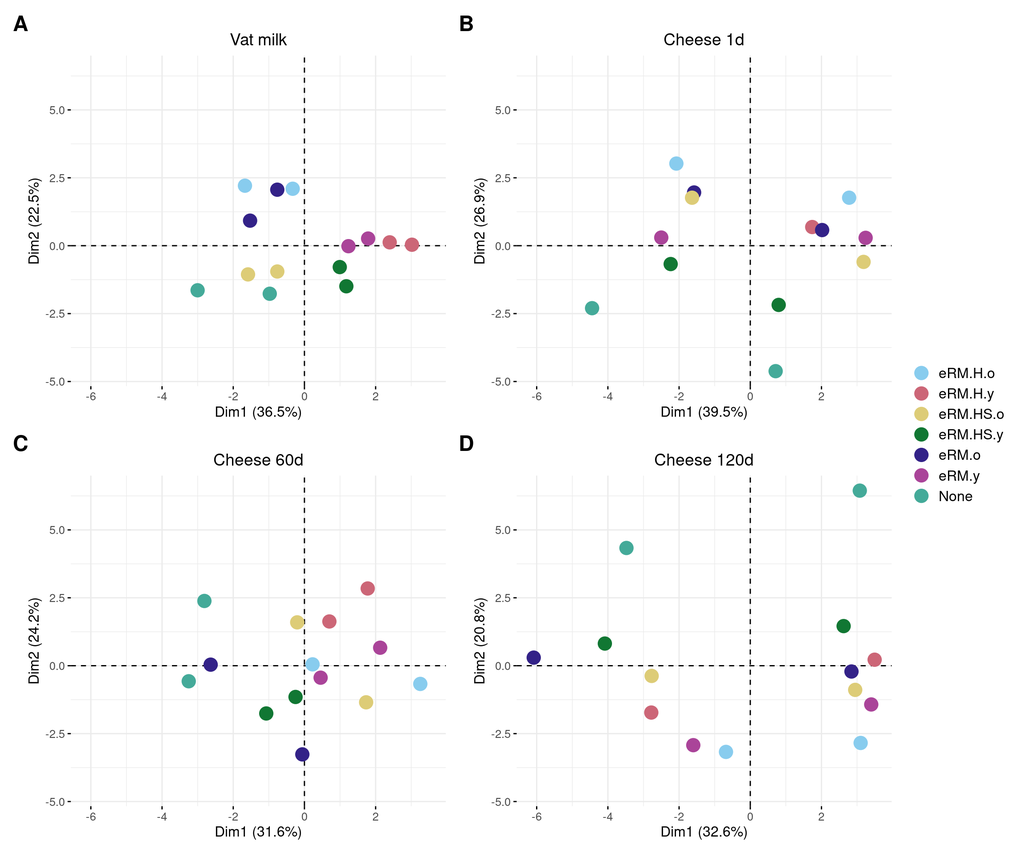

### Supplementary Plots

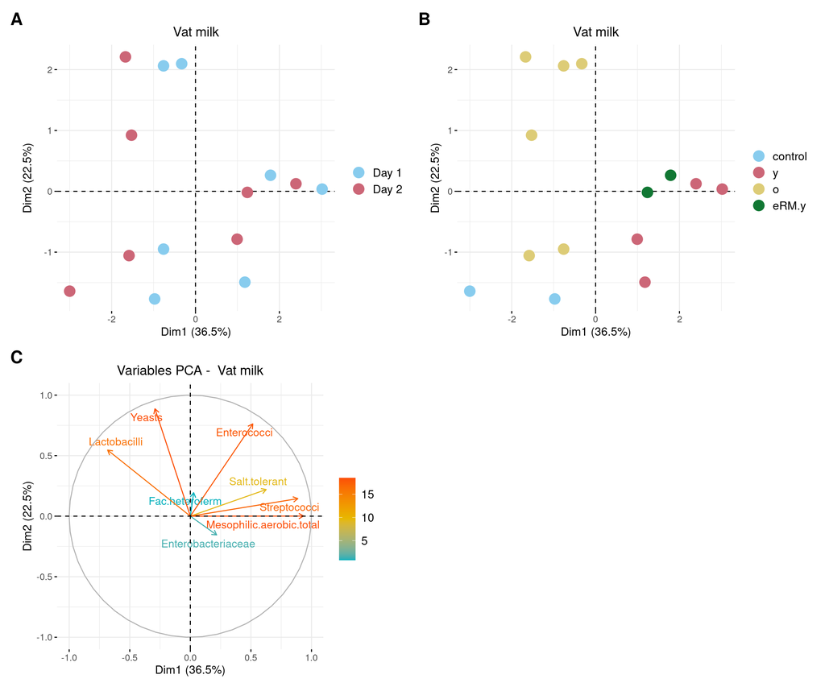

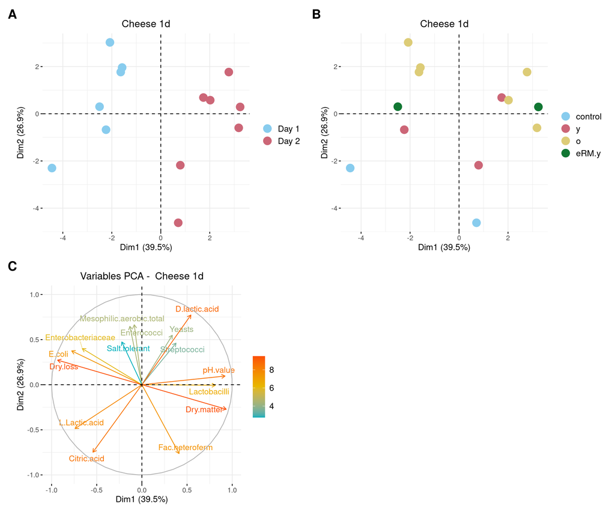

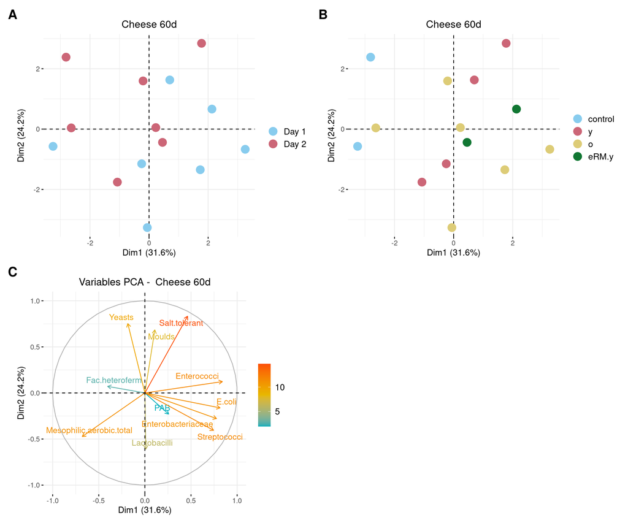

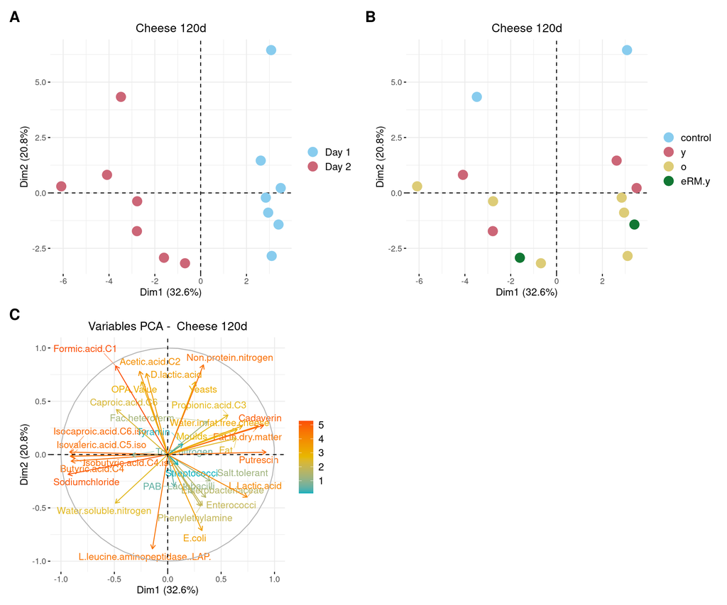